# Projet Statistiques Bayésiennes : Données Spotify

## Interprétation

## Etude des mcmc

## Fake data check

```r
generate_fake_data_beta <- function(n1, n2,alpha1_fake,alpha2_fake,beta1_fake,beta2_fake) {

  y1_fake <- rbeta(n1, alpha1_fake, beta1_fake)
  y2_fake <- rbeta(n1, alpha2_fake, beta2_fake)

  return(list(y1_fake = y1_fake, y2_fake = y2_fake))
}

generate_fake_data_gamma <- function(n1, n2,alpha1_fake,alpha2_fake,beta1_fake,beta2_fake) {

  # Générer des données factices à partir de la distribution de Poisson
  y1_fake <- rgamma(n1, alpha1_fake, beta1_fake)
  y2_fake <- rgamma(n1, alpha2_fake, beta2_fake)

  return(list(y1_fake = y1_fake, y2_fake = y2_fake))
}
```

```r
fake_data <- generate_fake_data_beta(length(acousticness_like), length(acousticness_dislike),0.5,0.9,0.5,0.7)

# Comparer les données factices avec les données réelles
summary(fake_data$y1_fake)
```

```
##      Min.   1st Qu.    Median      Mean   3rd Qu.      Max.
## 0.0000552 0.1326619 0.5196021 0.5157788 0.9134059 0.9999695
```

```r
summary(fake_data$y2_fake)
```

```
##     Min.  1st Qu.   Median     Mean  3rd Qu.     Max.
## 0.005683 0.314742 0.624674 0.574926 0.854566 0.999841
```

```r
summary(acousticness_like)
```

```
##     Min.  1st Qu.   Median     Mean  3rd Qu.     Max.
## 0.000111 0.168750 0.509000 0.489980 0.832750 0.994000
```

```r
summary(acousticness_dislike)
```

```
##      Min.   1st Qu.    Median      Mean   3rd Qu.      Max.
## 0.0000011 0.0127000 0.0839000 0.1674519 0.2132500 0.9510000
```

```r
data_list <- list(y1 = fake_data$y1_fake, y2 = fake_data$y2_fake, n1 = length(fake_data$y1_fake), n2 = length(fake_data$y2_fake))


# Compiling and producing posterior samples from the model.
jags_samples <- run.jags(model = model_string_acc, data = data_list, monitor = c("alpha1","alpha2", "beta1","beta2"))
```

```
## Compiling rjags model...
## Calling the simulation using the rjags method...
## Adapting the model for 1000 iterations...
## Burning in the model for 4000 iterations...
## Running the model for 10000 iterations...
## Simulation complete
## Calculating summary statistics...
## Calculating the Gelman-Rubin statistic for 4 variables....
## Finished running the simulation
```

```r
# Plotting and summarizing the posterior distribution
jags_samples
```

```
##
## JAGS model summary statistics from 20000 samples (chains = 2; adapt+burnin = 5000):
##
##        Lower95  Median Upper95    Mean       SD Mode      MCerr MC%ofSD SSeff
## alpha1 0.42333 0.49302 0.56711 0.49417 0.036657   -- 0.00041628     1.1  7754
## alpha2 0.76366 0.89416   1.033 0.89565 0.068949   -- 0.00087136     1.3  6261
## beta1  0.38302 0.44362 0.50819 0.44441 0.031946   -- 0.00036326     1.1  7734
## beta2  0.56593 0.65648 0.75008 0.65815 0.047519   --  0.0006108     1.3  6052
##
##              AC.10   psrf
## alpha1   0.0030525 1.0003
## alpha2  0.00094103 1.0008
## beta1   -0.0049676 1.0001
## beta2  -0.00044332 1.0003
##
## Total time taken: 1.4 minutes
```

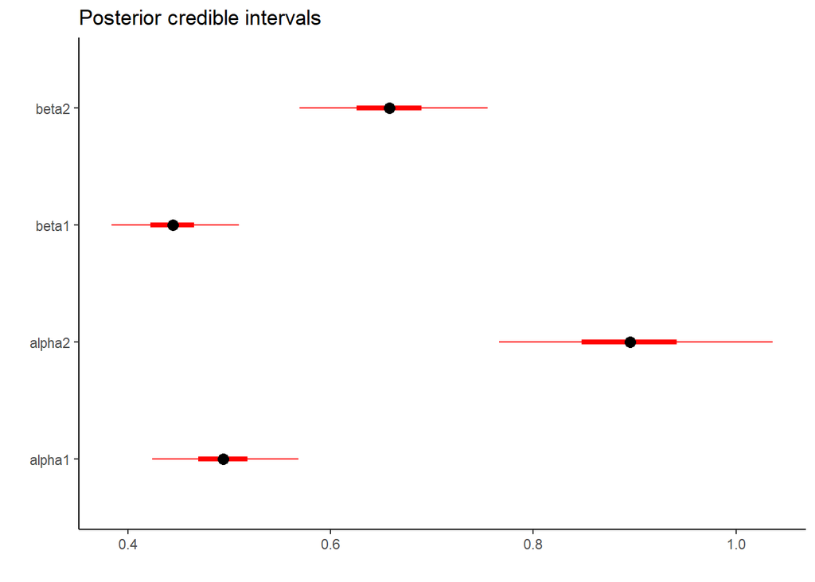

```r
plot_credible_intervals(jags_samples)
```

```r
summary(jags_samples)
```

```
##          Lower95    Median   Upper95      Mean         SD Mode        MCerr
## alpha1 0.4233280 0.4930209 0.5671143 0.4941728 0.03665651   NA 0.0004162840
## alpha2 0.7636637 0.8941625 1.0329759 0.8956465 0.06894857   NA 0.0008713628
## beta1  0.3830154 0.4436196 0.5081943 0.4444051 0.03194643   NA 0.0003632613
## beta2  0.5659320 0.6564825 0.7500756 0.6581517 0.04751861   NA 0.0006107982
##        MC%ofSD SSeff         AC.10     psrf
## alpha1     1.1  7754  0.0030525207 1.000321
## alpha2     1.3  6261  0.0009410313 1.000812
## beta1      1.1  7734 -0.0049675823 1.000107
## beta2      1.3  6052 -0.0004433179 1.000331
```

**Conclusion** :

# 8- Variable : instrumentalness

**description** Predicts whether a track contains no vocals. “Ooh” and “aah” sounds are treated as instrumental in this context. Rap or spoken word tracks are clearly “vocal”. The closer the instrumentalness value is to 1.0, the greater likelihood the track contains no vocal content. Values above 0.5 are intended to represent instrumental tracks, but confidence is higher as the value approaches 1.0.

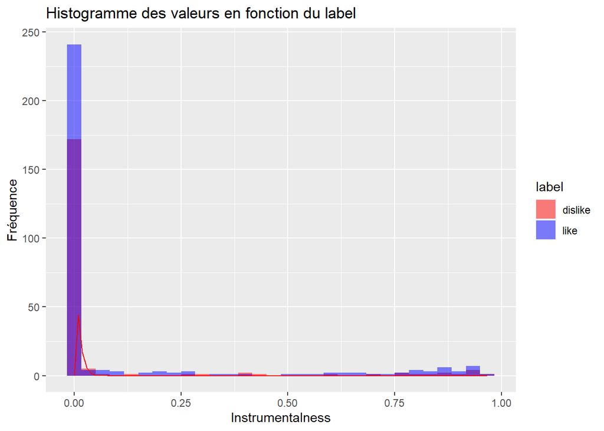

```r
gamma_density <- function(x, alpha, beta) {
  dgamma(x, shape = alpha, rate = beta)
}

ggplot(data, aes(x = instrumentalness, fill = label)) +
  geom_histogram(alpha = 0.5, position = "identity", bins = 30) +
  stat_function(fun = beta_density, args = list(1.3,120), color = "red") +# Add gamma density curve
  labs(title = "Histogramme des valeurs en fonction du label",
       x = "Instrumentalness",
       y = "Fréquence") +
  scale_fill_manual(values = c("red", "blue"))  # Définir les couleurs pour chaque label
```

## Modèle

```r
model_string_instr <- "
model {

  for (i in 1:n1){
    y1[i] ~ dgamma(alpha1,beta1)
  }
  for (i in 1:n2){
    y2[i] ~ dgamma(alpha2,beta2)
  }
  alpha1 ~ dunif(1,2);
  alpha2 ~ dunif(1,2);
  beta1 ~ dunif(100,150);
  beta2 ~ dunif(100,150);
}
"


y1 = instrumentalness_like+0.01
y2 = instrumentalness_dislike+0.01
data_list_instr <- list(y1 = y1, y2 = y2,n1 = length(y1), n2 =length(y2))
```

```r
# Compiling and producing posterior samples from the model.
jags_samples <- run.jags(model = model_string_instr, data = data_list_instr, monitor = c("alpha1","alpha2","beta1","beta2"))
```

```
## Compiling rjags model...
## Calling the simulation using the rjags method...
## Adapting the model for 1000 iterations...
## Burning in the model for 4000 iterations...
## Running the model for 10000 iterations...
## Simulation complete
## Calculating summary statistics...
## Calculating the Gelman-Rubin statistic for 4 variables....
## Finished running the simulation
```

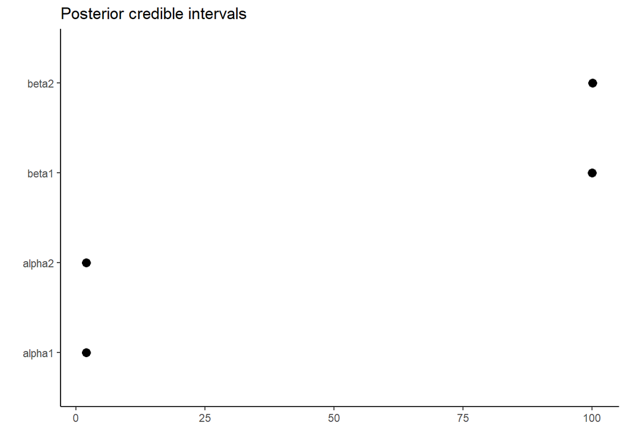

```r
plot_credible_intervals(jags_samples)
```

## Interprétation

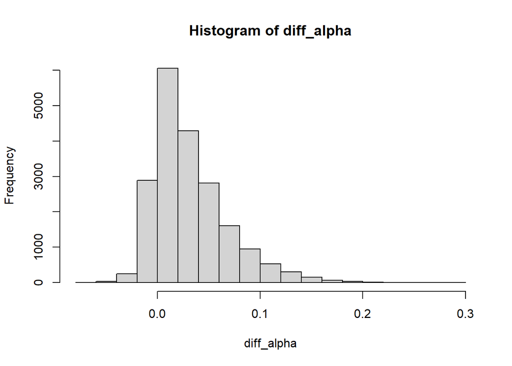

```r
s <- as.data.frame(jags_samples$mcmc %>% lapply(as_tibble) %>% bind_rows())

diff_alpha=s$alpha1 - s$alpha2
diff_beta=s$beta1 - s$beta2

mean_alpha=mean(s$alpha1 < s$alpha2)
mean_beta=mean(s$beta1 < s$beta2)

hist(diff_alpha)
```

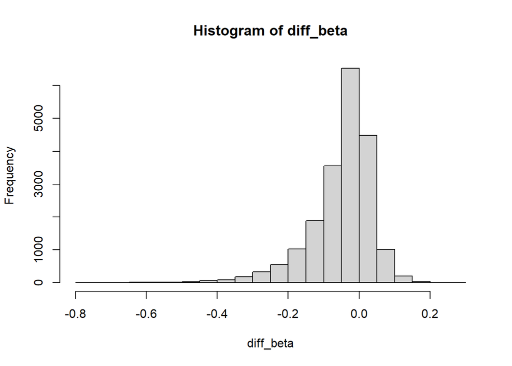

```r
hist(diff_beta)
```

## Etude des mcmc

## Fake data check

```r
fake_data <- generate_fake_data_gamma(length(instrumentalness_like), length(instrumentalness_dislike),1.1,1.8,120,140)

# Comparer les données factices avec les données réelles
summary(fake_data$y1_fake)
```

```
##      Min.   1st Qu.    Median      Mean   3rd Qu.      Max.
## 0.0001084 0.0028675 0.0063443 0.0090790 0.0118949 0.0846426
```

```r
summary(fake_data$y2_fake)
```

```
##      Min.   1st Qu.    Median      Mean   3rd Qu.      Max.
## 0.0001776 0.0056663 0.0111085 0.0125666 0.0174236 0.0526912
```

```r
summary(instrumentalness_like)
```

```
##      Min.   1st Qu.    Median      Mean   3rd Qu.      Max.
## 0.0000000 0.0000000 0.0000493 0.1113969 0.0061450 0.9560000
```

```r
summary(instrumentalness_dislike)
```

```
##      Min.   1st Qu.    Median      Mean   3rd Qu.      Max.
## 0.0000000 0.0000000 0.0000017 0.0711406 0.0005860 0.9670000
```

```r
data_list <- list(y1 = fake_data$y1_fake, y2 = fake_data$y2_fake, n1 = length(fake_data$y1_fake), n2 = length(fake_data$y2_fake))


# Compiling and producing posterior samples from the model.
jags_samples <- run.jags(model = model_string_instr, data = data_list, monitor = c("alpha1","alpha2", "beta1","beta2"))
```

```
## Compiling rjags model...
## Calling the simulation using the rjags method...
## Adapting the model for 1000 iterations...
## Burning in the model for 4000 iterations...
## Running the model for 10000 iterations...
## Simulation complete
## Calculating summary statistics...
## Calculating the Gelman-Rubin statistic for 4 variables....
## Finished running the simulation
```

```r
# Plotting and summarizing the posterior distribution
jags_samples
```

```
##
## JAGS model summary statistics from 20000 samples (chains = 2; adapt+burnin = 5000):
##
##        Lower95 Median Upper95   Mean       SD Mode     MCerr MC%ofSD SSeff
## alpha1  1.0001 1.1228   1.249 1.1275 0.069252   -- 0.0011765     1.7  3465
## alpha2     1.6 1.7973  1.9733 1.7903 0.096654   -- 0.0016919     1.8  3263
## beta1   106.44 123.89  144.23 124.34   9.8107   --     0.164     1.7  3579
## beta2   125.84 141.75     150 140.21   7.4135   --   0.13689     1.8  2933
##
##           AC.10   psrf
## alpha1 0.050369 1.0009
## alpha2 0.054353      1
## beta1  0.048284 1.0006
## beta2  0.066395      1
##
## Total time taken: 1.3 minutes
```

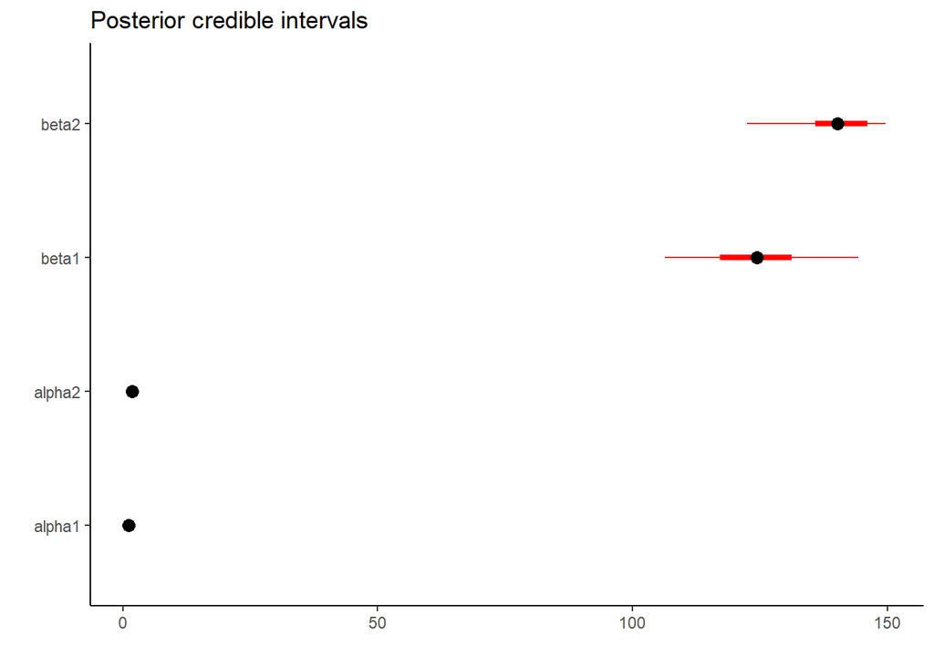

```r
plot_credible_intervals(jags_samples)
```

```r
summary(jags_samples)
```

```
##           Lower95     Median    Upper95       Mean         SD Mode       MCerr
## alpha1   1.000117   1.122802   1.248979   1.127544 0.06925212   NA 0.001176513
## alpha2   1.600010   1.797320   1.973312   1.790268 0.09665415   NA 0.001691925
## beta1  106.442234 123.894304 144.226224 124.338057 9.81068504   NA 0.163996919
## beta2  125.844963 141.745161 149.996910 140.206014 7.41354411   NA 0.136893889
##        MC%ofSD SSeff      AC.10     psrf
## alpha1     1.7  3465 0.05036873 1.000921
## alpha2     1.8  3263 0.05435323 1.000027
## beta1      1.7  3579 0.04828450 1.000578
## beta2      1.8  2933 0.06639533 1.000033
```

**Conclusion** :

# 9- Variable : liveness

**description**Detects the presence of an audience in the recording. Higher liveness values represent an increased probability that the track was performed live. A value above 0.8 provides strong likelihood that the track is live.

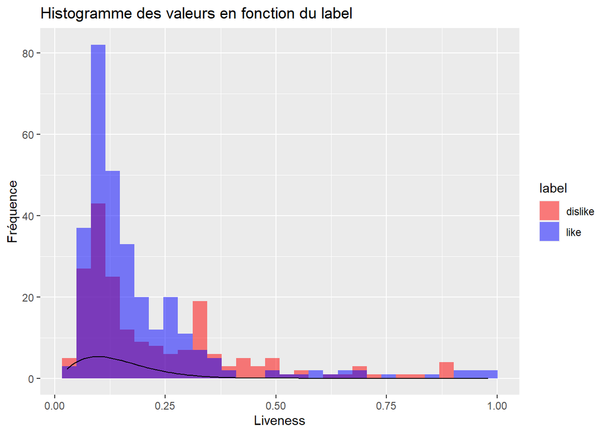

```r
beta_density <- function(x, alpha, beta) {
  dbeta(x, shape1 = alpha, shape2 = beta)
}

ggplot(data, aes(x = liveness, fill = label)) +
  geom_histogram(alpha = 0.5, position = "identity", bins = 30) +
  stat_function(fun = beta_density, args = list(alpha = 2.5, beta = 15), color = "black") +  # Add gamma density curve
  labs(title = "Histogramme des valeurs en fonction du label",
       x = "Liveness",
       y = "Fréquence") +
  scale_fill_manual(values = c("red", "blue"))  # Définir les couleurs pour chaque label
```

Observation, on en déduit une loi beta

## Modèle

```r
model_string_liv <- "
model {
  alpha1 ~ dunif(0,3);
  alpha2 ~ dunif(0,3);
  beta1 ~ dunif(10,20);
  beta2 ~ dunif(10,20);

  for (i in 1:n1) {
    y1[i] ~ dbeta(alpha1,beta1);
  }

  for (i in 1:n2) {
    y2[i] ~ dbeta(alpha2,beta2);
  }
}
"


data_list_liv <- list(y1 = liveness_like,  y2 = liveness_dislike,
                  n1 = length(liveness_like), n2 = length(liveness_dislike))

# Compiling and producing posterior samples from the model.
jags_samples <- run.jags(model = model_string_liv, data = data_list_liv, monitor = c("alpha1","alpha2", "beta1","beta2"))
```

```
## Compiling rjags model...
## Calling the simulation using the rjags method...
## Adapting the model for 1000 iterations...
## Burning in the model for 4000 iterations...
## Running the model for 10000 iterations...
## Simulation complete
## Calculating summary statistics...
## Calculating the Gelman-Rubin statistic for 4 variables....
## Finished running the simulation
```

```r
# Plotting and summarizing the posterior distribution
jags_samples
```

```
##
## JAGS model summary statistics from 20000 samples (chains = 2; adapt+burnin = 5000):
##
##        Lower95 Median Upper95   Mean       SD Mode      MCerr MC%ofSD SSeff
## alpha1  2.0892 2.2455  2.4164 2.2467 0.084102   -- 0.00074524     0.9 12736
## alpha2  2.3126 2.5264  2.7545  2.528  0.11338   --  0.0010521     0.9 11614
## beta1       10 10.041  10.171 10.058 0.056593   -- 0.00091443     1.6  3830
## beta2       10 10.046  10.193 10.065 0.064482   --  0.0010143     1.6  4042
##
##             AC.10    psrf
## alpha1   0.019536       1
## alpha2 0.00060213 0.99996
## beta1    0.034323  1.0004
## beta2    0.012963  1.0095
##
## Total time taken: 1.6 minutes
```

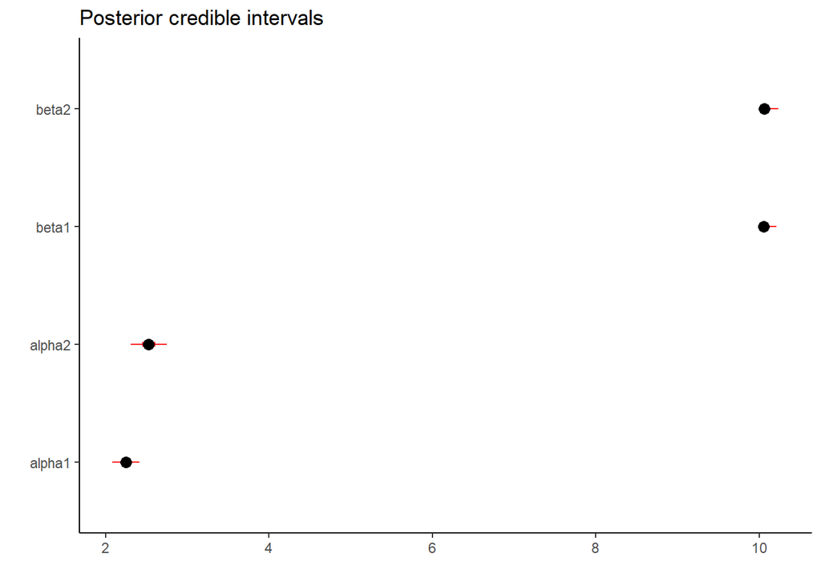

```r
plot_credible_intervals(jags_samples)
```

## Interprétation

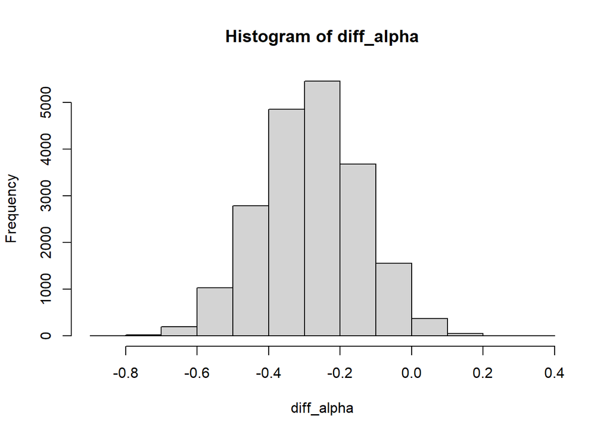

```r
s <- as.data.frame(jags_samples$mcmc %>% lapply(as_tibble) %>% bind_rows())

diff_alpha=s$alpha1 - s$alpha2
diff_beta=s$beta1 - s$beta2

mean_alpha=mean(s$alpha1 < s$alpha2)
mean_beta=mean(s$beta1 < s$beta2)

hist(diff_alpha)
```

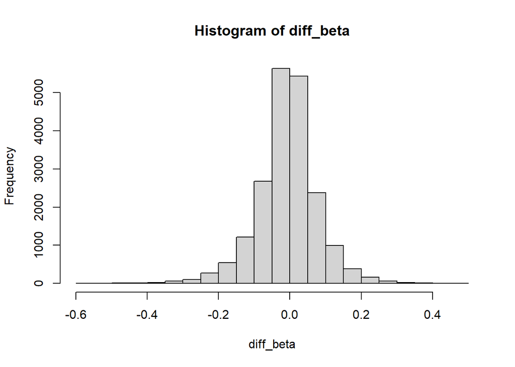

```r
hist(diff_beta)
```

## Etude des mcmc

## Fake data check

```r
#Liveness##

# Générer des données factices à partir des échantillons postérieurs
fake_data <- generate_fake_data_beta(length(liveness_like), length(liveness_dislike),2.5,1.2,12,19)

# Comparer les données factices avec les données réelles
summary(fake_data$y1_fake)
```

```
##    Min. 1st Qu.  Median    Mean 3rd Qu.    Max.
##  0.0110  0.1052  0.1649  0.1764  0.2368  0.6209
```

```r
summary(fake_data$y2_fake)
```

```
##      Min.   1st Qu.    Median      Mean   3rd Qu.      Max.
## 0.0002087 0.0230285 0.0477903 0.0627220 0.0915770 0.2404229
```

```r
summary(liveness_like)
```

```
##    Min. 1st Qu.  Median    Mean 3rd Qu.    Max.
##  0.0348  0.1003  0.1275  0.1881  0.2145  0.9790
```

```r
summary(liveness_dislike)
```

```
##    Min. 1st Qu.  Median    Mean 3rd Qu.    Max.
## 0.02770 0.09455 0.14550 0.22736 0.33050 0.87900
```

```r
data_list <- list(y1 = fake_data$y1_fake, y2 = fake_data$y2_fake, n1 = length(fake_data$y1_fake), n2 = length(fake_data$y2_fake))


# Compiling and producing posterior samples from the model.
jags_samples <- run.jags(model = model_string_liv, data = data_list, monitor = c("alpha1","alpha2", "beta1","beta2"))
```

```
## Compiling rjags model...
## Calling the simulation using the rjags method...
## Adapting the model for 1000 iterations...
## Burning in the model for 4000 iterations...
## Running the model for 10000 iterations...
## Simulation complete
## Calculating summary statistics...
## Calculating the Gelman-Rubin statistic for 4 variables....
## Finished running the simulation
```

```r
# Plotting and summarizing the posterior distribution
jags_samples
```

```
##
## JAGS model summary statistics from 20000 samples (chains = 2; adapt+burnin = 5000):
##
##        Lower95 Median Upper95   Mean       SD Mode     MCerr MC%ofSD SSeff
## alpha1  2.5486 2.8346       3 2.8086  0.13763   -- 0.0027905       2  2432
## alpha2  1.0935 1.2374  1.3814 1.2352 0.074019   -- 0.0011357     1.5  4248
## beta1   11.533 13.191  14.569 13.131  0.78393   --  0.015272     1.9  2635
## beta2   16.156 18.423      20 18.263   1.1453   --  0.018709     1.6  3748
##
##            AC.10   psrf
## alpha1  0.098243 1.0004
## alpha2 0.0096165 1.0001
## beta1   0.080035 1.0001
## beta2   0.012621 1.0001
##
## Total time taken: 1.6 minutes
```

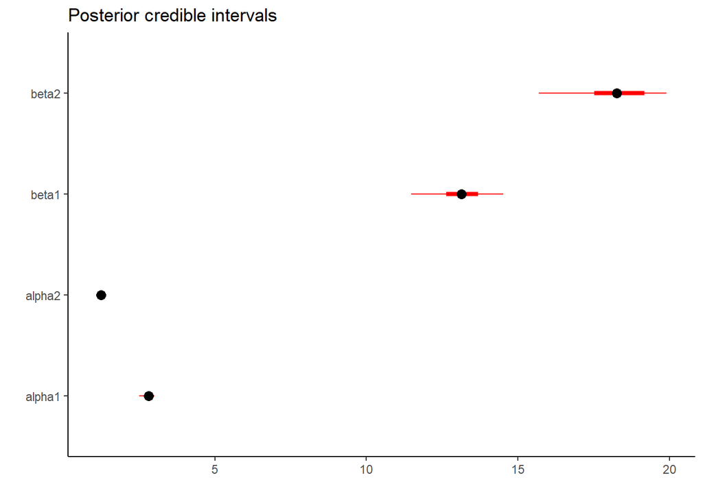

```r
plot_credible_intervals(jags_samples)
```

```r
summary(jags_samples)
```

```
##          Lower95    Median   Upper95      Mean         SD Mode       MCerr
## alpha1  2.548559  2.834565  2.999971  2.808604 0.13762865   NA 0.002790531
## alpha2  1.093513  1.237412  1.381400  1.235245 0.07401885   NA 0.001135702
## beta1  11.532996 13.191055 14.568730 13.131182 0.78393429   NA 0.015272396
## beta2  16.155966 18.422657 19.999776 18.263398 1.14534452   NA 0.018709204
##        MC%ofSD SSeff      AC.10     psrf
## alpha1     2.0  2432 0.09824292 1.000360
## alpha2     1.5  4248 0.00961653 1.000079
## beta1      1.9  2635 0.08003531 1.000135
## beta2      1.6  3748 0.01262070 1.000083
```

**Conclusion** :

# 10- Variable : valence

**Description :**

## Modèles

```r
model_string_valence <- "
model {
  mu1 ~ dunif(0, 1)
  mu2 ~ dunif(0, 1)
  sigma1 ~ dunif(0, 1)
  sigma2 ~ dunif(0, 1)

  for (i in 1:n1) {
    y1[i] ~ dnorm(mu1, precision1)
  }

  for (i in 1:n2) {
    y2[i] ~ dnorm(mu2, precision2)
  }

  precision1 <- 1 / (sigma1 * sigma1)
  precision2 <- 1 / (sigma2 * sigma2)
}
"

# Définition des données
y1 <- valence_like
y2 <- valence_dislike
data_list <- list(y1 = y1, y2 = y2, n1 = length(y1), n2 = length(y2))
# Compiling and producing posterior samples from the model.
jags_samples <- run.jags(model = model_string_valence, data = data_list, monitor = c("mu1", "mu2","sigma1","sigma2"))
```

```
## Compiling rjags model...
## Calling the simulation using the rjags method...
## Adapting the model for 1000 iterations...
## Burning in the model for 4000 iterations...
## Running the model for 10000 iterations...
## Simulation complete
## Calculating summary statistics...
## Calculating the Gelman-Rubin statistic for 4 variables....
## Finished running the simulation
```

```r
jags_samples
```

```
##
## JAGS model summary statistics from 20000 samples (chains = 2; adapt+burnin = 5000):
##
##        Lower95  Median Upper95    Mean        SD Mode       MCerr MC%ofSD SSeff
## mu1    0.42236 0.44743 0.47377 0.44746  0.013162   --  0.00011719     0.9 12615
## mu2    0.52638 0.55963 0.59304  0.5598  0.016943   --  0.00015383     0.9 12131
## sigma1 0.21324 0.23197 0.25026 0.23222 0.0094662   -- 0.000084372     0.9 12588
## sigma2 0.21549  0.2373 0.26187 0.23788  0.011938   --  0.00011245     0.9 11270
##
##              AC.10    psrf
## mu1     -0.0067864       1
## mu2    -0.00017419       1
## sigma1   0.0080379 0.99999
## sigma2    0.012541  1.0001
##
## Total time taken: 12.7 seconds
```

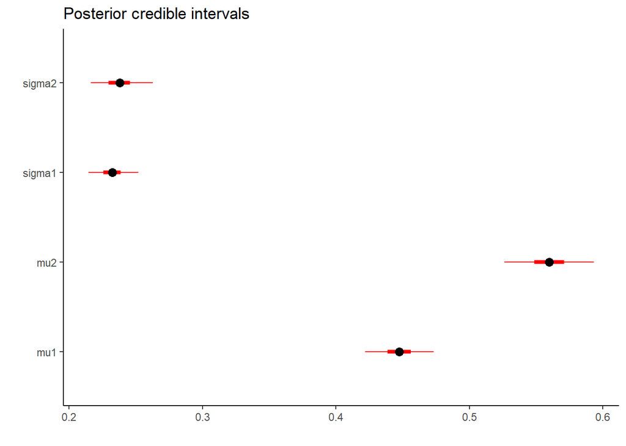

```r
plot_credible_intervals(jags_samples)
```

## Interprétation

```r
jags_samples_df <- as.data.frame(as.mcmc(jags_samples))

mean(jags_samples_df$mu1 < jags_samples_df$mu2)
```

```
## [1] 1
```

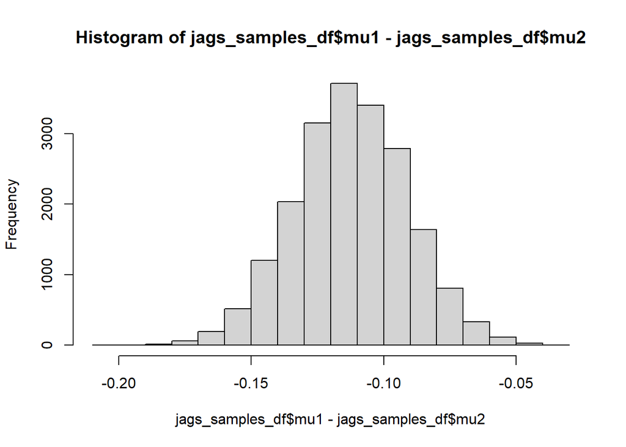

```r
hist(jags_samples_df$mu1 - jags_samples_df$mu2)
```

## Etude des mcmc

```
## Generating plots...
```

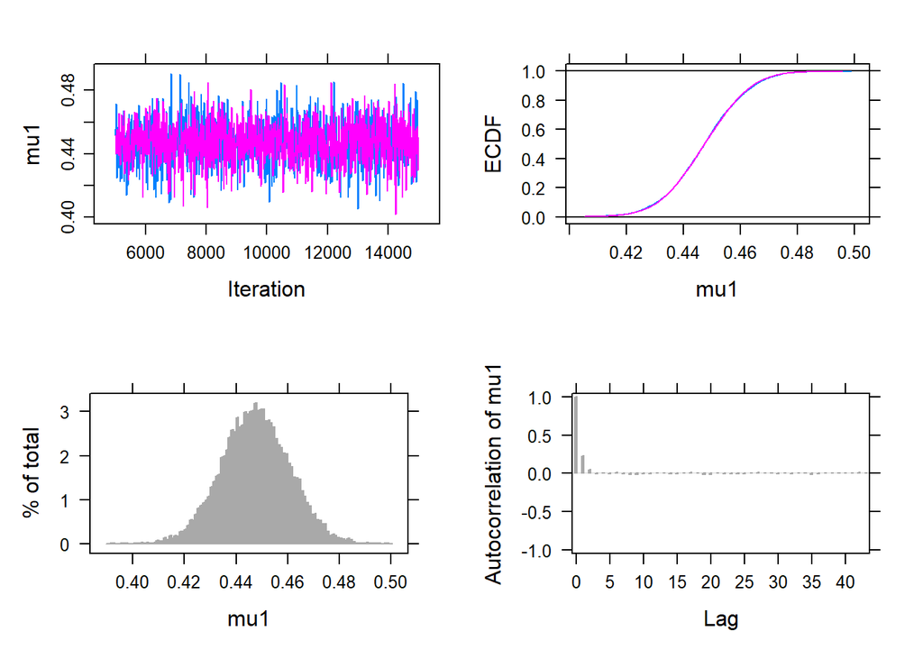

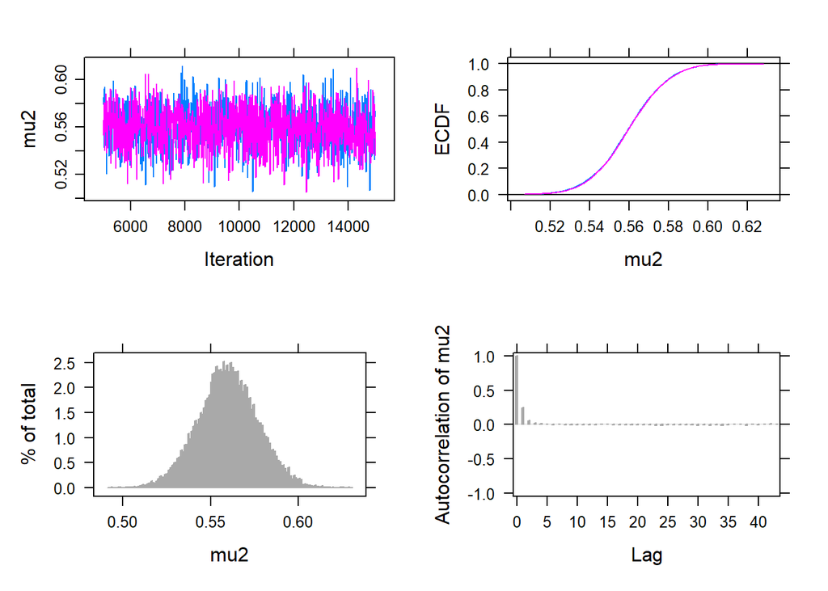

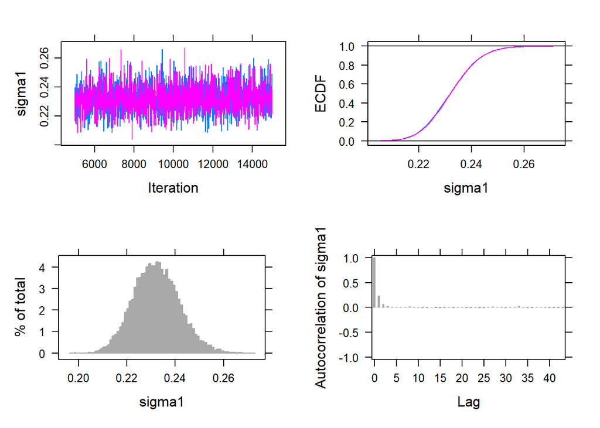

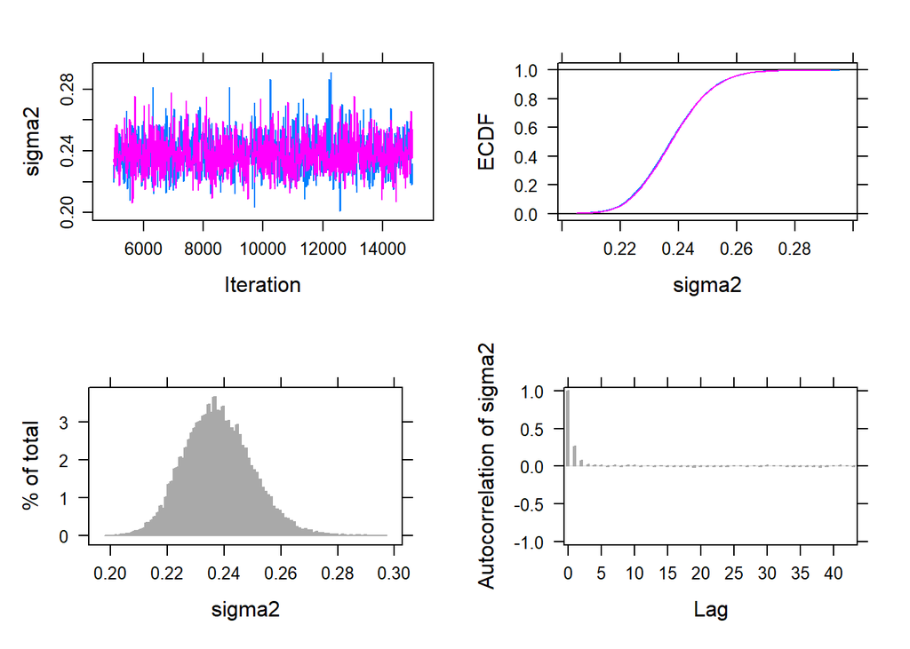

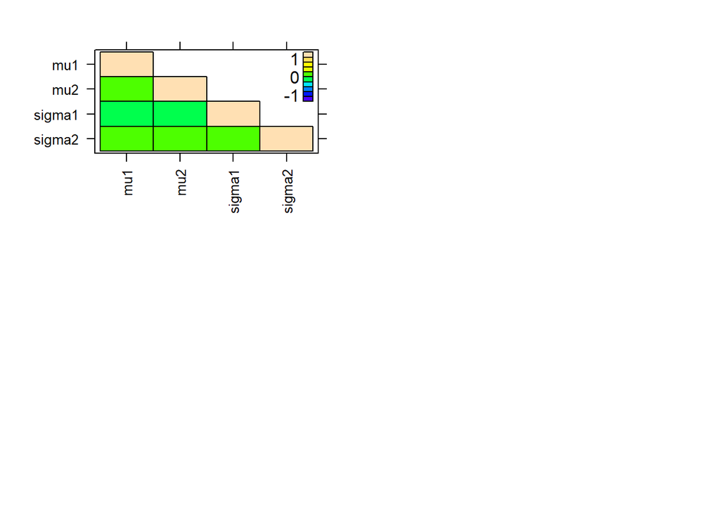

```r
plot(jags_samples)
```

```r
gelman.diag(jags_samples)
```

```
## Potential scale reduction factors:
##
##        Point est. Upper C.I.
## mu1             1          1
## mu2             1          1
## sigma1          1          1
## sigma2          1          1
##
## Multivariate psrf
##
## 1
```

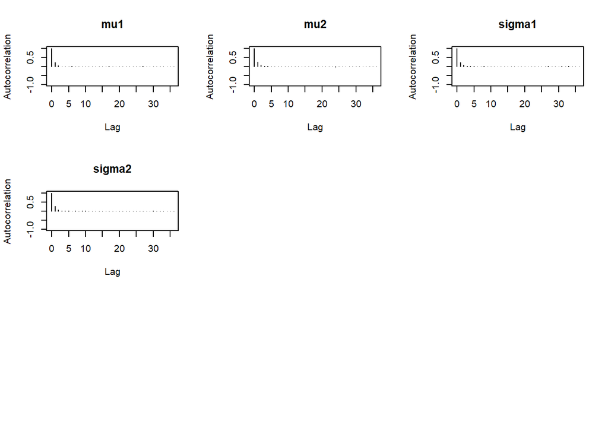

```r
autocorr.plot(jags_samples)
```

## Fake data check

```r
generate_fake_data <- function(n1, n2) {
  mu1_fake <- 0.5  # Utiliser la médiane au lieu de la moyenne
  mu2_fake <- 0.5

  sigma1_fake<-0.1
  sigma2_fake<-0.1

  # Générer des données factices à partir de la distribution de Poisson
  y1_fake <- rnorm(n1, mu1_fake,sigma1_fake)
  y2_fake <- rnorm(n2, mu2_fake,sigma2_fake)

  return(list(y1_fake = y1_fake, y2_fake = y2_fake))
}

# Générer des données factices à partir des échantillons postérieurs
fake_data <- generate_fake_data(length(valence_like), length(valence_dislike))

# Comparer les données factices avec les données réelles
summary(fake_data$y1_fake)
```

```
##    Min. 1st Qu.  Median    Mean 3rd Qu.    Max.
##  0.1777  0.4266  0.5013  0.4948  0.5648  0.8124
```

```r
summary(fake_data$y2_fake)
```

```
##    Min. 1st Qu.  Median    Mean 3rd Qu.    Max.
##  0.2318  0.4373  0.4979  0.5009  0.5674  0.7426
```

```r
summary(y1)
```

```
##    Min. 1st Qu.  Median    Mean 3rd Qu.    Max.
##  0.0384  0.2482  0.4380  0.4474  0.6268  0.9680
```

```r
summary(y2)
```

```
##    Min. 1st Qu.  Median    Mean 3rd Qu.    Max.
##  0.0381  0.3947  0.5570  0.5596  0.7430  0.9670
```

```r
data_list <- list(y1 = fake_data$y1_fake, y2 = fake_data$y2_fake, n1 = length(fake_data$y1_fake), n2 = length(fake_data$y2_fake))


# Compiling and producing posterior samples from the model.
jags_samples <- run.jags(model = model_string_valence, data = data_list, monitor = c("mu1", "mu2","sigma1","sigma2"))
```

```
## Compiling rjags model...
## Calling the simulation using the rjags method...
## Adapting the model for 1000 iterations...
## Burning in the model for 4000 iterations...
## Running the model for 10000 iterations...
## Simulation complete
## Calculating summary statistics...
## Calculating the Gelman-Rubin statistic for 4 variables....
## Finished running the simulation
```

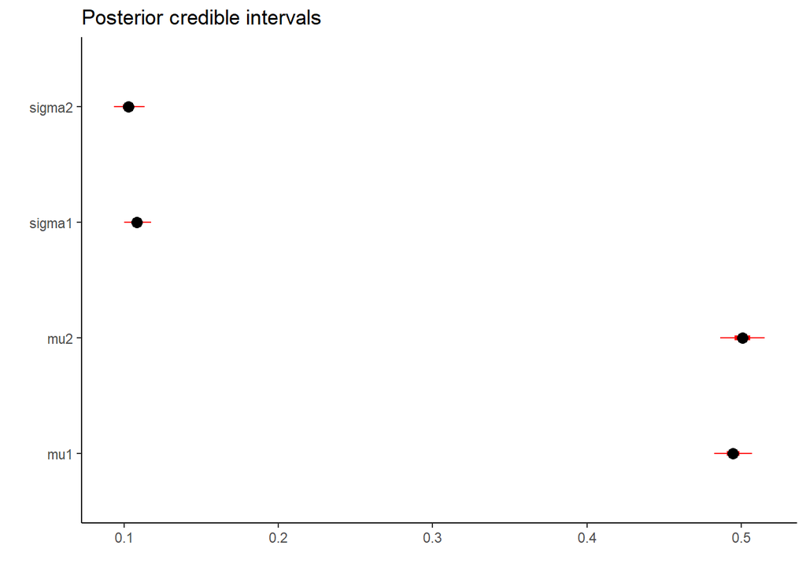

```r
# Plotting and summarizing the posterior distribution
plot_credible_intervals(jags_samples)
```

```r
summary(jags_samples)
```

```
##           Lower95    Median   Upper95      Mean          SD Mode        MCerr
## mu1    0.48253345 0.4948076 0.5072318 0.4948401 0.006309685   NA 5.662549e-05
## mu2    0.48695502 0.5008806 0.5155118 0.5009183 0.007304315   NA 6.538749e-05
## sigma1 0.09972195 0.1080129 0.1169269 0.1081833 0.004422627   NA 4.024470e-05
## sigma2 0.09311952 0.1022746 0.1129959 0.1025429 0.005155110   NA 4.738191e-05
##        MC%ofSD SSeff        AC.10      psrf
## mu1        0.9 12416  0.004635721 1.0002305
## mu2        0.9 12479  0.004571158 1.0003586
## sigma1     0.9 12077  0.011973964 1.0002016
## sigma2     0.9 11837 -0.015201431 0.9999634
```

**Conclusion** :

## Interprétation

# 11- Variable : tempo

**Description :**

## Modèle

```r
model_string_tempo <- "
model {
  mu1 ~ dunif(0, 2000)
  mu2 ~ dunif(0, 2000)
  sigma1 ~ dunif(0, 1000)
  sigma2 ~ dunif(0, 1000)

  for (i in 1:n1) {
    y1[i] ~ dnorm(mu1, precision1)
  }

  for (i in 1:n2) {
    y2[i] ~ dnorm(mu2, precision2)
  }

  precision1 <- 1 / (sigma1 * sigma1)
  precision2 <- 1 / (sigma2 * sigma2)
}
"

# Définition des données
y1 <- tempo_like
y2 <- tempo_dislike
data_list <- list(y1 = y1, y2 = y2, n1 = length(y1), n2 = length(y2))
# Compiling and producing posterior samples from the model.
jags_samples <- run.jags(model = model_string_tempo, data = data_list, monitor = c("mu1", "mu2","sigma1","sigma2"))
```

```
## Compiling rjags model...
## Calling the simulation using the rjags method...
## Adapting the model for 1000 iterations...
## Burning in the model for 4000 iterations...
## Running the model for 10000 iterations...
## Simulation complete
## Calculating summary statistics...
## Calculating the Gelman-Rubin statistic for 4 variables....
## Finished running the simulation
```

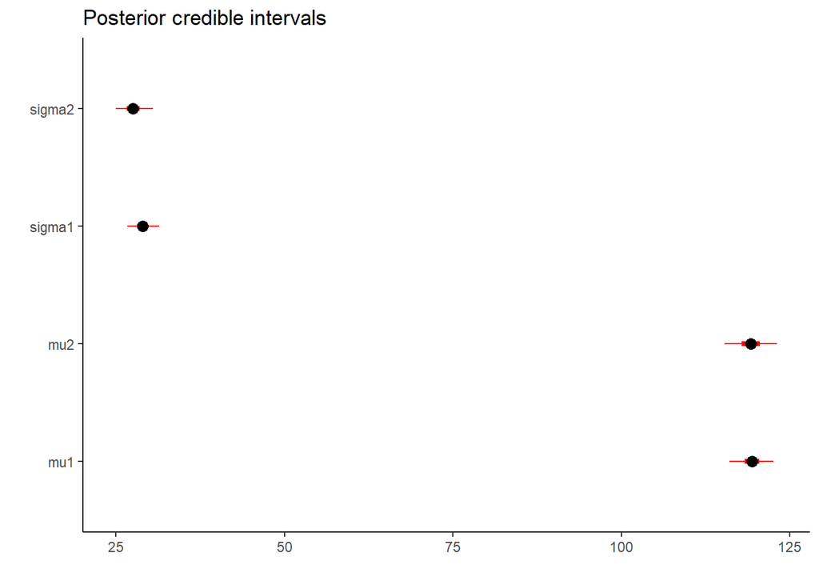

```r
plot_credible_intervals(jags_samples)
```

## Interprétation

```r
s <- as.data.frame(jags_samples$mcmc %>% lapply(as_tibble) %>% bind_rows())
head(s)
```

```
##        mu1      mu2   sigma1   sigma2
## 1 119.4915 116.6121 27.41403 25.34142
## 2 116.5543 116.1833 27.35962 29.55071
## 3 120.4741 117.1089 30.27743 26.70060
## 4 117.9370 120.7821 28.73935 28.20439
## 5 117.1404 117.6744 28.60682 25.27495
## 6 117.0298 120.7729 28.69197 25.31814
```

```r
 # The probability that the rate theta1 is smaller than theta2
mean(s$mu1 < s$mu2)
```

```
## [1] 0.46825
```

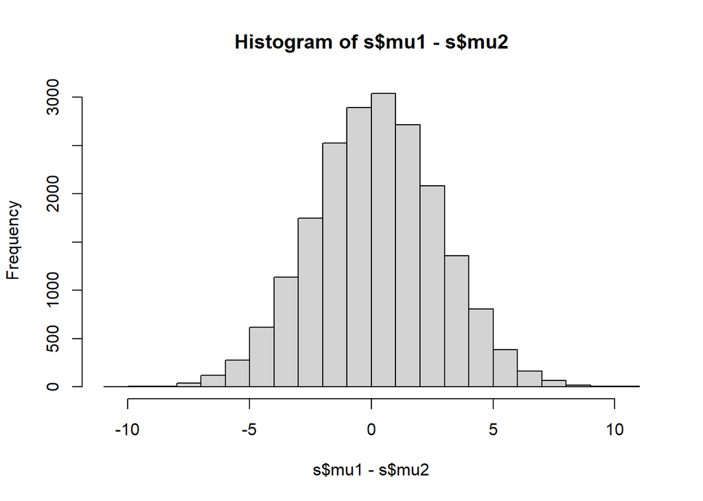

```r
# The above is a short cut for sum(s$theta1 < s$theta2) / nrow(s)

# Plotting distribution of the difference between theta1 and theta2
hist(s$mu1 - s$mu2)
```

## Etude des mcmc

```
## Generating plots...
```

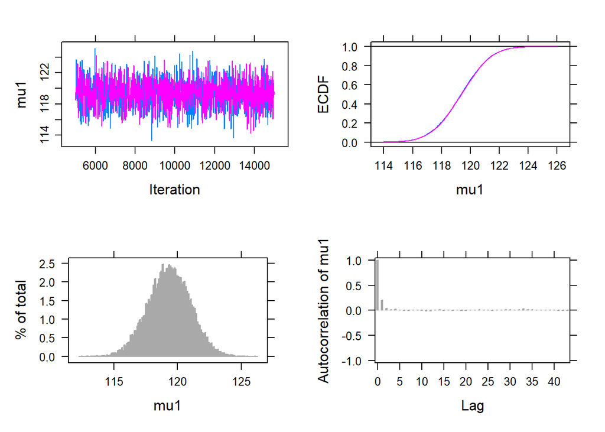

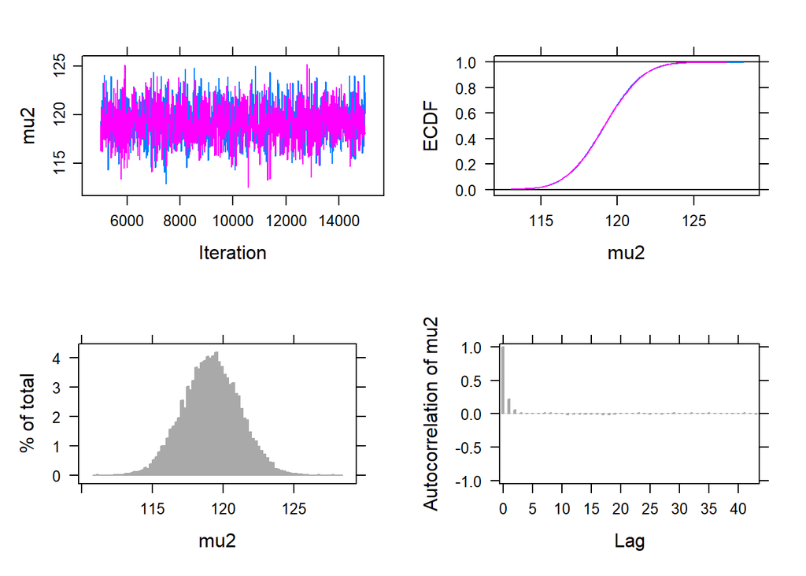

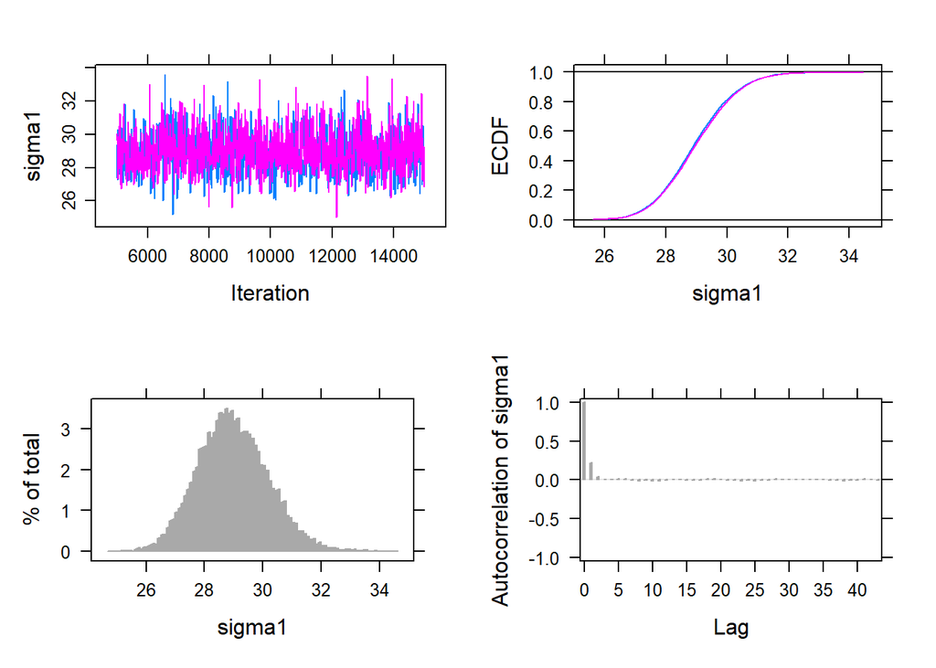

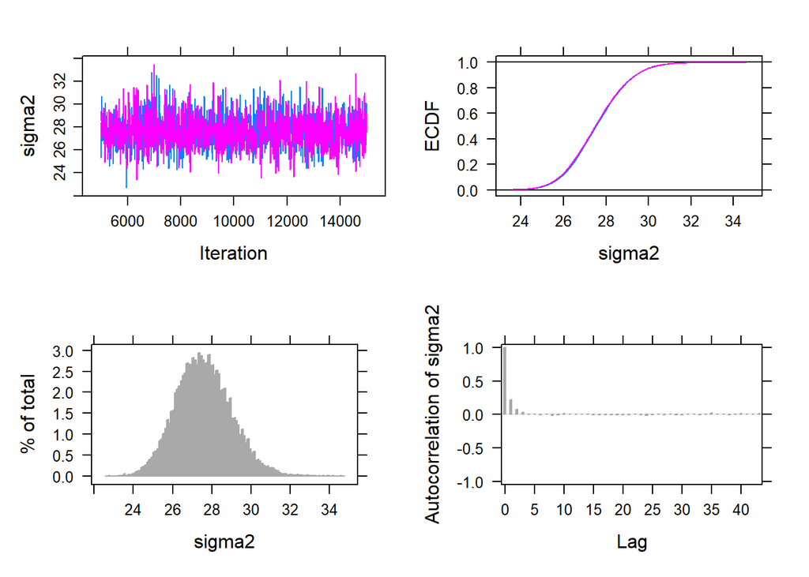

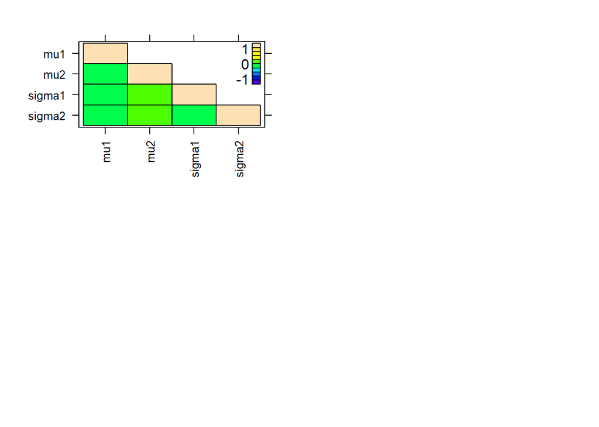

```r
plot(jags_samples)
```

```r
gelman.diag(jags_samples)
```

```
## Potential scale reduction factors:
##
##        Point est. Upper C.I.
## mu1             1          1
## mu2             1          1
## sigma1          1          1
## sigma2          1          1
##
## Multivariate psrf
##
## 1
```

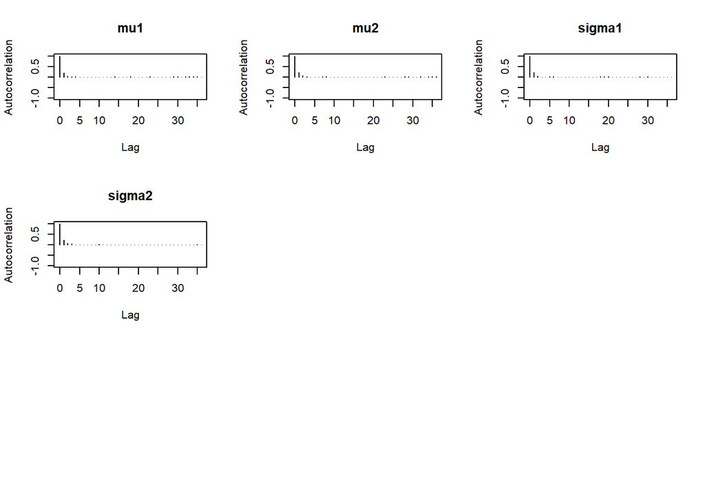

```r
autocorr.plot(jags_samples)
```

## Fake data

```r
generate_fake_data <- function(n1, n2) {
  mu1_fake <- 100 # Utiliser la médiane au lieu de la moyenne
  mu2_fake <- 129

  sigma1_fake<-20
  sigma2_fake<-10

  # Générer des données factices à partir de la distribution de Poisson
  y1_fake <- rnorm(n1, mu1_fake,sigma1_fake)
  y2_fake <- rnorm(n2, mu2_fake,sigma2_fake)

  return(list(y1_fake = y1_fake, y2_fake = y2_fake))
}

# Générer des données factices à partir des échantillons postérieurs
fake_data <- generate_fake_data(length(valence_like), length(valence_dislike))

# Comparer les données factices avec les données réelles
summary(fake_data$y1_fake)
```

```
##    Min. 1st Qu.  Median    Mean 3rd Qu.    Max.
##   45.70   87.26  100.26   99.82  111.56  140.94
```

```r
summary(fake_data$y2_fake)
```

```
##    Min. 1st Qu.  Median    Mean 3rd Qu.    Max.
##   98.99  122.06  129.65  128.99  136.91  151.67
```

```r
summary(y1)
```

```
##    Min. 1st Qu.  Median    Mean 3rd Qu.    Max.
##   55.75   96.70  119.93  119.37  138.00  219.98
```

```r
summary(y2)
```

```
##    Min. 1st Qu.  Median    Mean 3rd Qu.    Max.
##   71.78   96.02  117.97  119.14  132.69  203.71
```

```r
data_list <- list(y1 = fake_data$y1_fake, y2 = fake_data$y2_fake, n1 = length(fake_data$y1_fake), n2 = length(fake_data$y2_fake))


# Compiling and producing posterior samples from the model.
jags_samples <- run.jags(model = model_string_tempo, data = data_list, monitor = c("mu1", "mu2","sigma1","sigma2"))
```

```
## Compiling rjags model...
## Calling the simulation using the rjags method...
## Adapting the model for 1000 iterations...
## Burning in the model for 4000 iterations...
## Running the model for 10000 iterations...
## Simulation complete
## Calculating summary statistics...
## Calculating the Gelman-Rubin statistic for 4 variables....
## Finished running the simulation
```

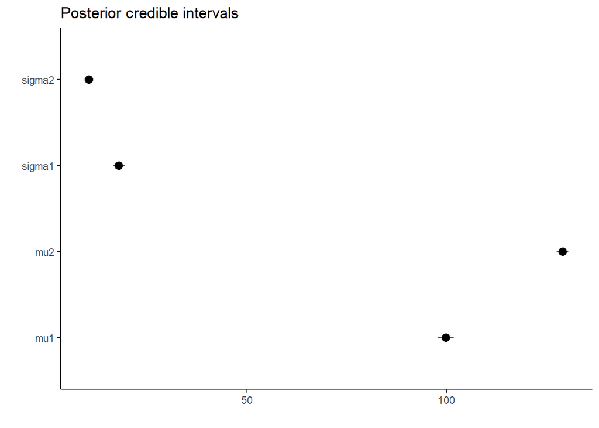

```r
plot_credible_intervals(jags_samples)
```

**Conclusion** :

# 12- Variable : duration

**Description :**

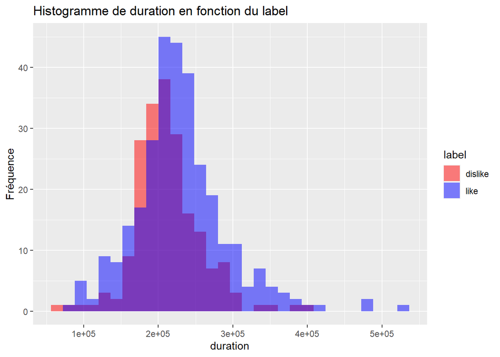

```r
ggplot(data, aes(x = duration, fill = label)) +
    geom_histogram(alpha = 0.5, position = "identity", bins = 30) +
    labs(title = "Histogramme de duration en fonction du label",
         x = "duration",
         y = "Fréquence") +
    scale_fill_manual(values = c("red", "blue"))
```

## Modèles

```r
model_string_duration <- "
model {
  mu1 ~ dunif(180000, 240000)
  mu2 ~ dunif(180000, 240000)
  sigma1 ~ dunif(0, 100000)
  sigma2 ~ dunif(0, 100000)

  for (i in 1:n1) {
    y1[i] ~ dnorm(mu1, precision1)
  }

  for (i in 1:n2) {
    y2[i] ~ dnorm(mu2, precision2)
  }

  precision1 <- 1 / (sigma1 * sigma1)
  precision2 <- 1 / (sigma2 * sigma2)
}
"

# Définition des données
y1 <- duration_like
y2 <- duration_dislike
data_list_duration <- list(y1 = y1, y2 = y2, n1 = length(y1), n2 = length(y2))
# Compiling and producing posterior samples from the model.
jags_samples <- run.jags(model = model_string_duration, data = data_list_duration, monitor = c("mu1", "mu2","sigma1","sigma2"))
```

```
## Compiling rjags model...
## Calling the simulation using the rjags method...
## Adapting the model for 1000 iterations...
## Burning in the model for 4000 iterations...
## Running the model for 10000 iterations...
## Simulation complete
## Calculating summary statistics...
## Calculating the Gelman-Rubin statistic for 4 variables....
## Finished running the simulation
```

```r
# Plotting and summarizing the posterior distribution
jags_samples
```

```
##
## JAGS model summary statistics from 20000 samples (chains = 2; adapt+burnin = 5000):
##
##        Lower95 Median Upper95   Mean     SD Mode  MCerr MC%ofSD SSeff
## mu1     222785 229912  236814 229899 3568.2   -- 32.152     0.9 12317
## mu2     206048 212540  219006 212548 3304.7   -- 30.655     0.9 11621
## sigma1   57710  62615   67849  62706 2608.9   -- 24.864       1 11009
## sigma2   41887  46255   51123  46348 2369.5   --  22.55       1 11041
##
##             AC.10    psrf
## mu1    -0.0054033  1.0011
## mu2     0.0061082 0.99996
## sigma1   0.017841  1.0009
## sigma2  -0.011245  1.0001
##
## Total time taken: 12.7 seconds
```

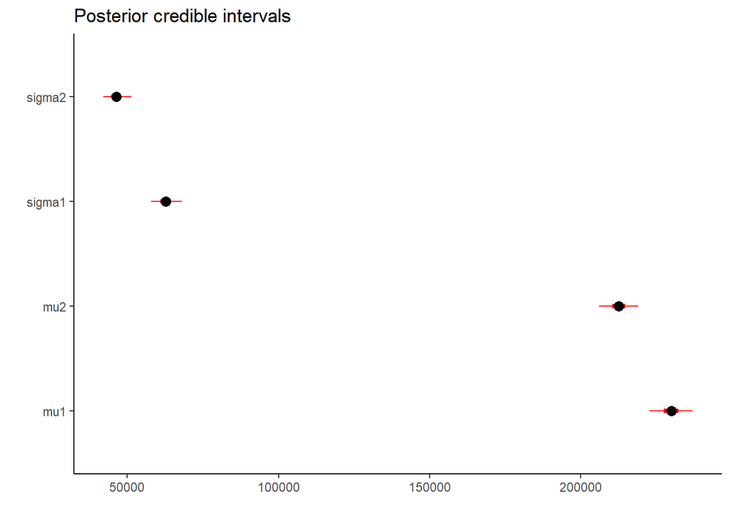

```r
plot_credible_intervals(jags_samples)
```

**Trace plots** : Les graphiques de trace montrent l’évolution des chaînes de Markov générées par l’échantillonnage de Monte Carlo par chaîne de Markov (MCMC) pour chaque paramètre du modèle. Ils permettent de vérifier la convergence des chaînes en examinant si elles semblent se stabiliser autour d’une valeur ou si elles continuent à errer. Une convergence satisfaisante est indiquée par des trajectoires qui se chevauchent et restent stationnaires après un certain nombre d’itérations.

**Statistique Gelman-Rubin** : Cette statistique est utilisée pour évaluer la convergence des chaînes MCMC en comparant la variance intra-chaîne avec la variance inter-chaîne. Une valeur proche de 1 (par exemple, inférieure à 1,1) indique une convergence satisfaisante. Des valeurs significativement plus élevées suggèrent que les chaînes n’ont pas convergé.

**Graphiques d’autocorrélation** : Ces graphiques montrent l’autocorrélation des échantillons de chaînes MCMC à différentes retards. Ils permettent d’évaluer la dépendance entre les échantillons successifs. Des autocorrélations élevées à des retards élevés peuvent indiquer une mauvaise efficacité d’échantillonnage. Idéalement, on cherche à minimiser l’autocorrélation pour obtenir des échantillons indépendants.

Taille effective de l’échantillon : C’est une mesure de l’efficacité d’échantillonnage des chaînes MCMC. Étant donné que les échantillons ne sont pas indépendants en raison de l’autocorrélation, la taille effective de l’échantillon est généralement inférieure à la taille réelle de l’échantillon. Elle est calculée en prenant en compte l’autocorrélation entre les échantillons. Une taille effective plus élevée indique une meilleure efficacité d’échantillonnage.

En résumé, ces diagnostics sont utilisés pour évaluer la convergence et la qualité des échantillons générés par les méthodes MCMC. Une fois que les chaînes sont convergentes et que les échantillons sont jugés suffisamment indépendants et efficaces, on peut utiliser ces échantillons pour estimer les quantités d’intérêt et effectuer des inférences sur le modèle bayésien ajusté.

## Interprétation

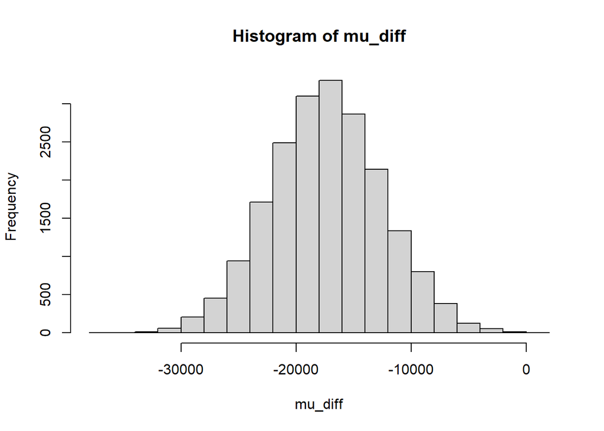

```r
# Conversion des échantillons JAGS en un data frame
jags_samples_df <- as.data.frame(as.mcmc(jags_samples))

# Calcul de la différence entre mu2 et mu1
mu_diff <- jags_samples_df$mu2 - jags_samples_df$mu1



# Tracé de l'histogramme
hist(mu_diff)
```

```r
mean(mu_diff < 0)
```

```
## [1] 0.99985
```

## Etude des mcmc

```r
# Vérification de la convergence de l'algorithme MCMC
print(jags_samples)
```

```
##
## JAGS model summary statistics from 20000 samples (chains = 2; adapt+burnin = 5000):
##
##        Lower95 Median Upper95   Mean     SD Mode  MCerr MC%ofSD SSeff
## mu1     222785 229912  236814 229899 3568.2   -- 32.152     0.9 12317
## mu2     206048 212540  219006 212548 3304.7   -- 30.655     0.9 11621
## sigma1   57710  62615   67849  62706 2608.9   -- 24.864       1 11009
## sigma2   41887  46255   51123  46348 2369.5   --  22.55       1 11041
##
##             AC.10    psrf
## mu1    -0.0054033  1.0011
## mu2     0.0061082 0.99996
## sigma1   0.017841  1.0009
## sigma2  -0.011245  1.0001
##
## Total time taken: 12.7 seconds
```

```
## Generating plots...
```

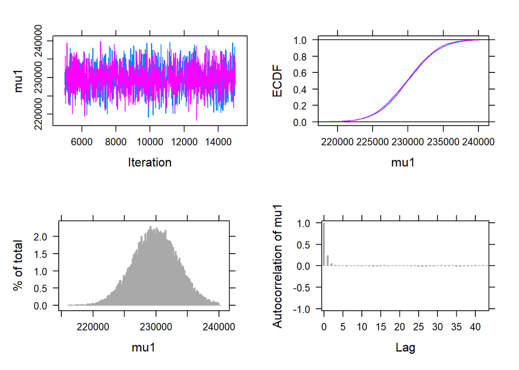

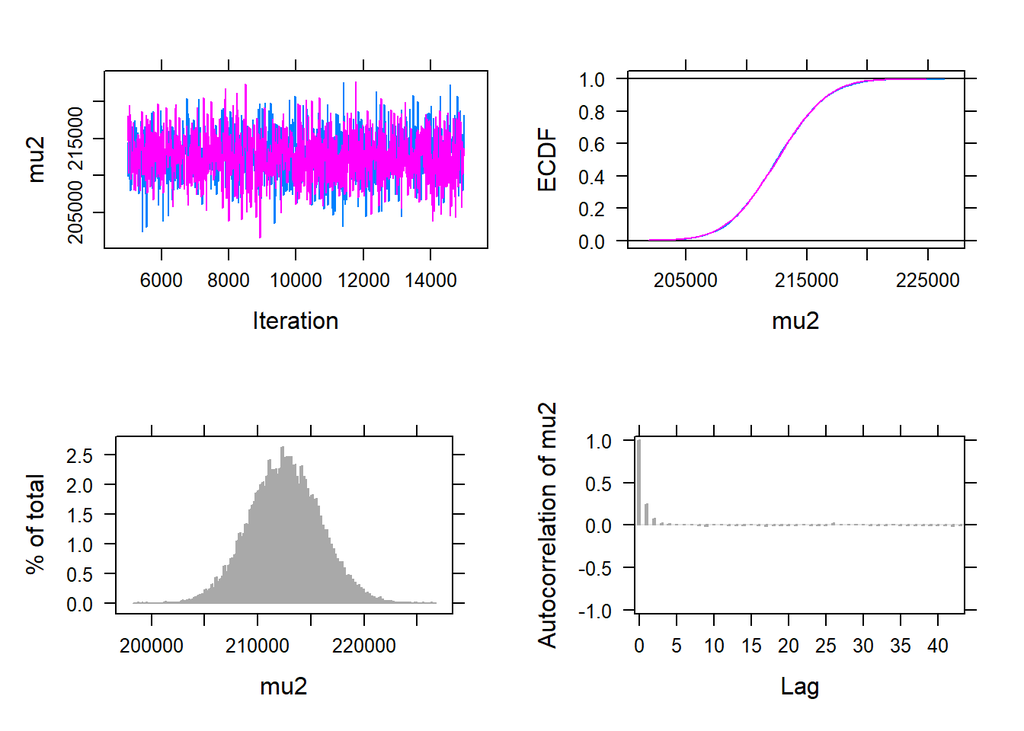

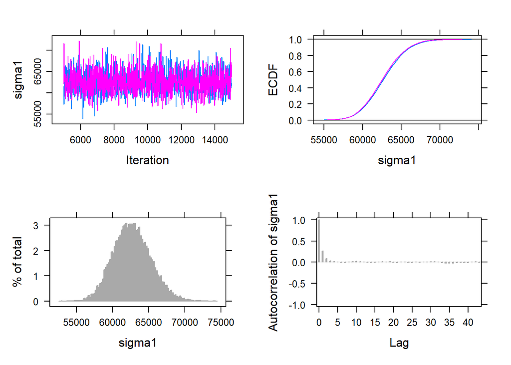

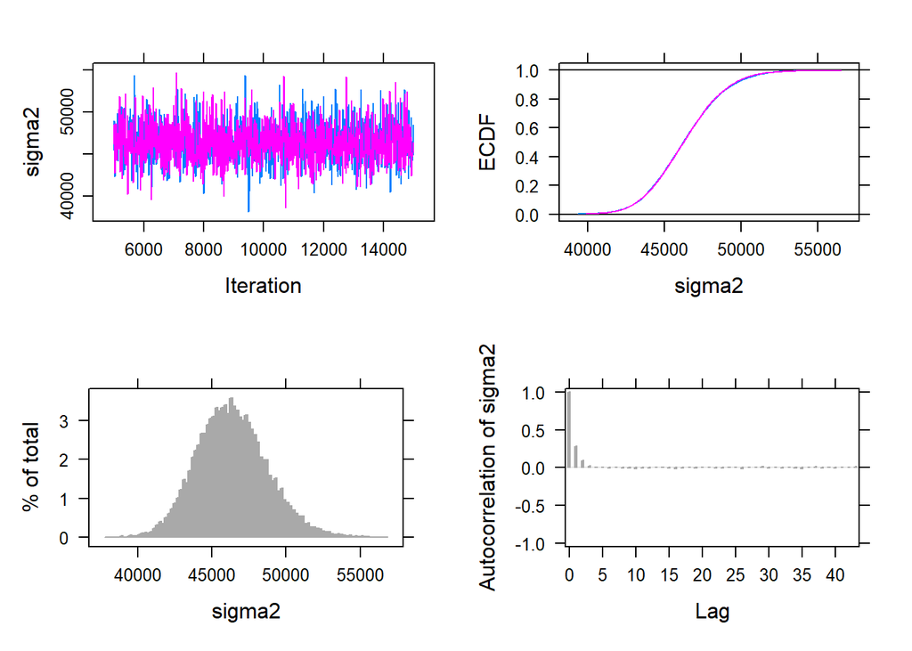

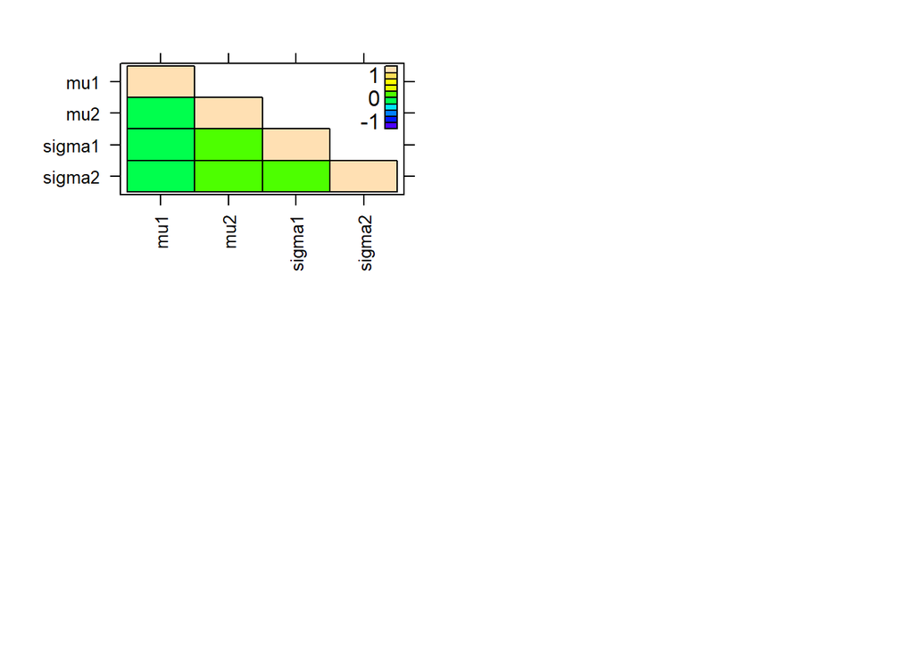

```r
# Tracer les diagnostics de convergence
plot(jags_samples)
```

```
## Generating plots...
```

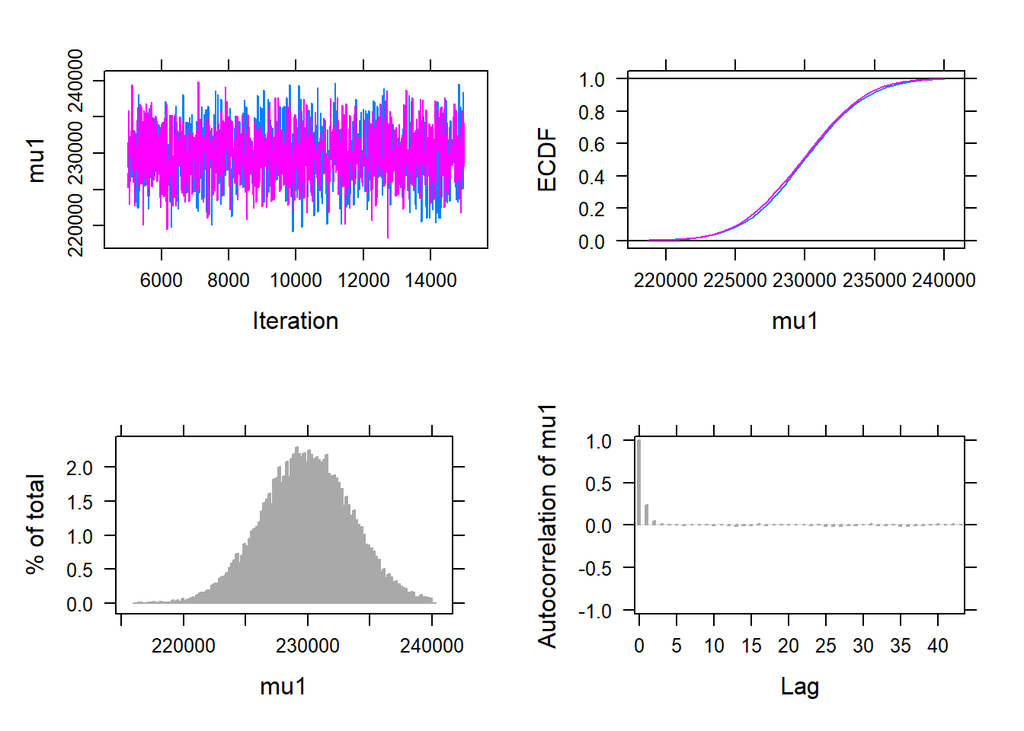

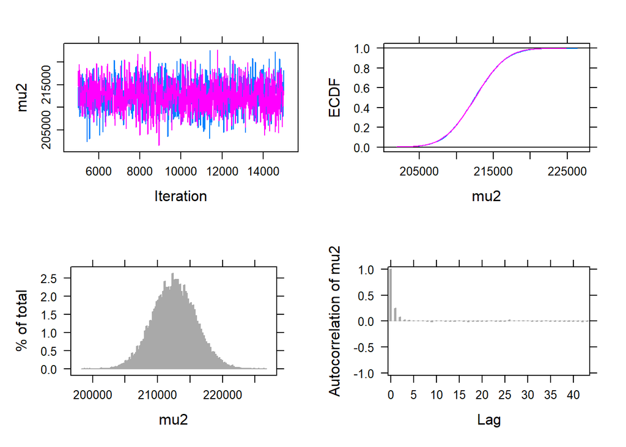

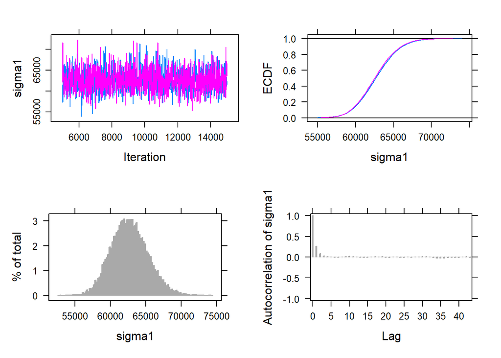

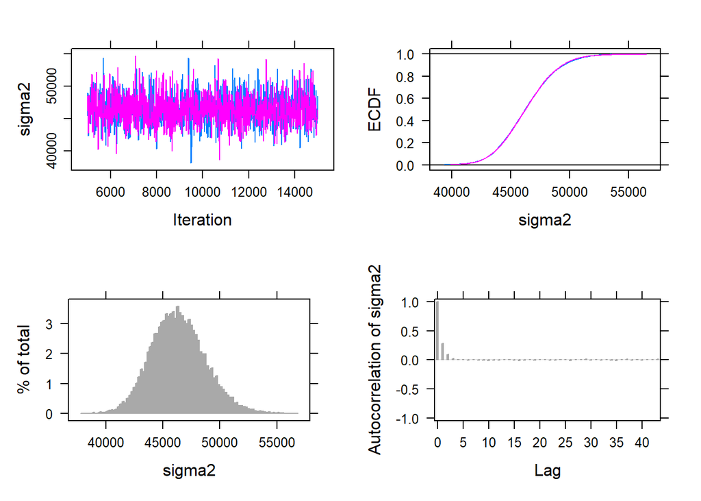

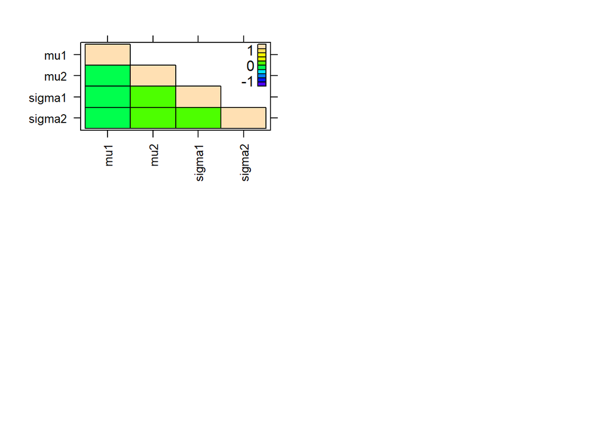

```r
# Trace plots
plot(jags_samples)
```

```r
# Gelman-Rubin statistic
gelman.diag(jags_samples)
```

```
## Potential scale reduction factors:
##
##        Point est. Upper C.I.
## mu1             1       1.01
## mu2             1       1.00
## sigma1          1       1.01
## sigma2          1       1.00
##
## Multivariate psrf
##
## 1
```

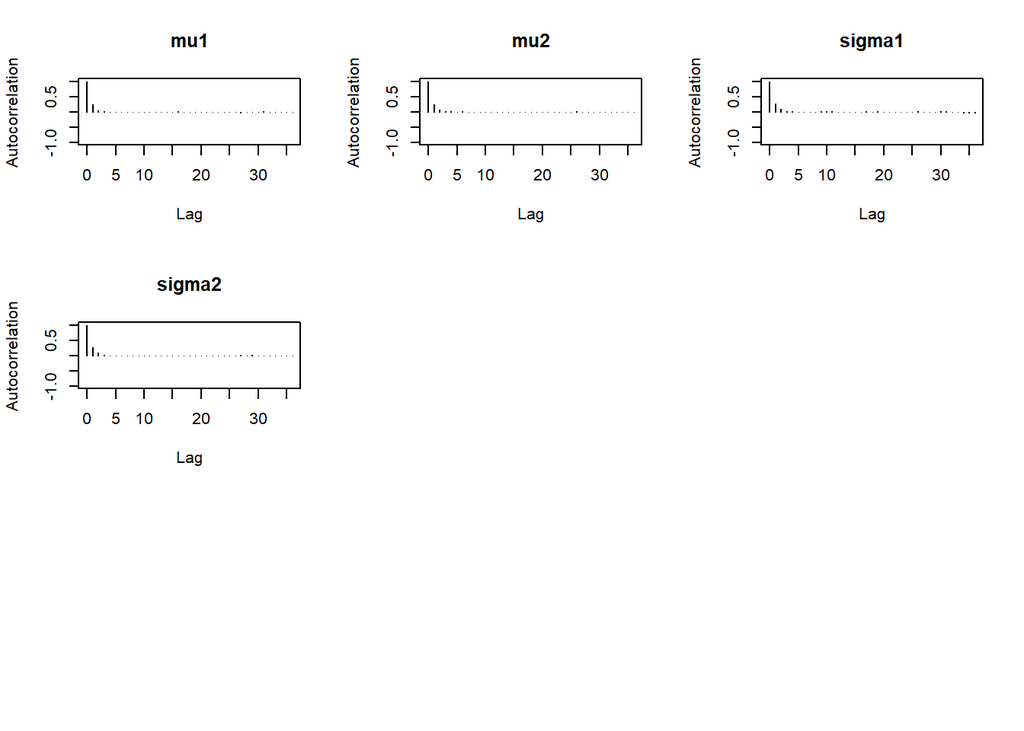

```r
# Autocorrelation plots
autocorr.plot(jags_samples)
```

```r
# Effective sample size
effectiveSize(jags_samples)
```

```
##      mu1      mu2   sigma1   sigma2
## 12287.68 11732.21 11146.94 10957.88
```

## Fake data check

```r
generate_fake_data <- function(n1, n2) {
  mu1_fake <- 200000 # Utiliser la médiane au lieu de la moyenne
  mu2_fake <- 230000

  sigma1_fake<-40000
  sigma2_fake<-60000

  # Générer des données factices à partir de la distribution de Poisson
  y1_fake <- rnorm(n1, mu1_fake,sigma1_fake)
  y2_fake <- rnorm(n2, mu2_fake,sigma2_fake)

  return(list(y1_fake = y1_fake, y2_fake = y2_fake))
}

# Générer des données factices à partir des échantillons postérieurs
fake_data <- generate_fake_data(length(duration_like), length(duration_dislike))


data_list <- list(y1 = fake_data$y1_fake, y2 = fake_data$y2_fake, n1 = length(fake_data$y1_fake), n2 = length(fake_data$y2_fake))


# Compiling and producing posterior samples from the model.
jags_samples <- run.jags(model = model_string_duration, data = data_list, monitor = c("mu1", "mu2","sigma1","sigma2"))
```

```
## Compiling rjags model...
## Calling the simulation using the rjags method...
## Adapting the model for 1000 iterations...
## Burning in the model for 4000 iterations...
## Running the model for 10000 iterations...
## Simulation complete
## Calculating summary statistics...
## Calculating the Gelman-Rubin statistic for 4 variables....
## Finished running the simulation
```

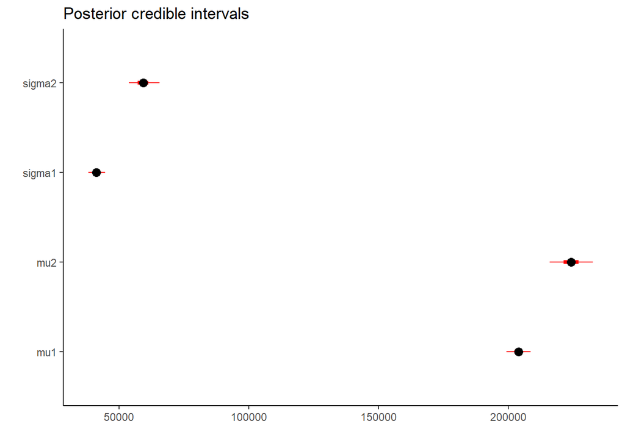

```r
plot_credible_intervals(jags_samples)
```

**Conclusion** :

# 13- Variable : time_signature

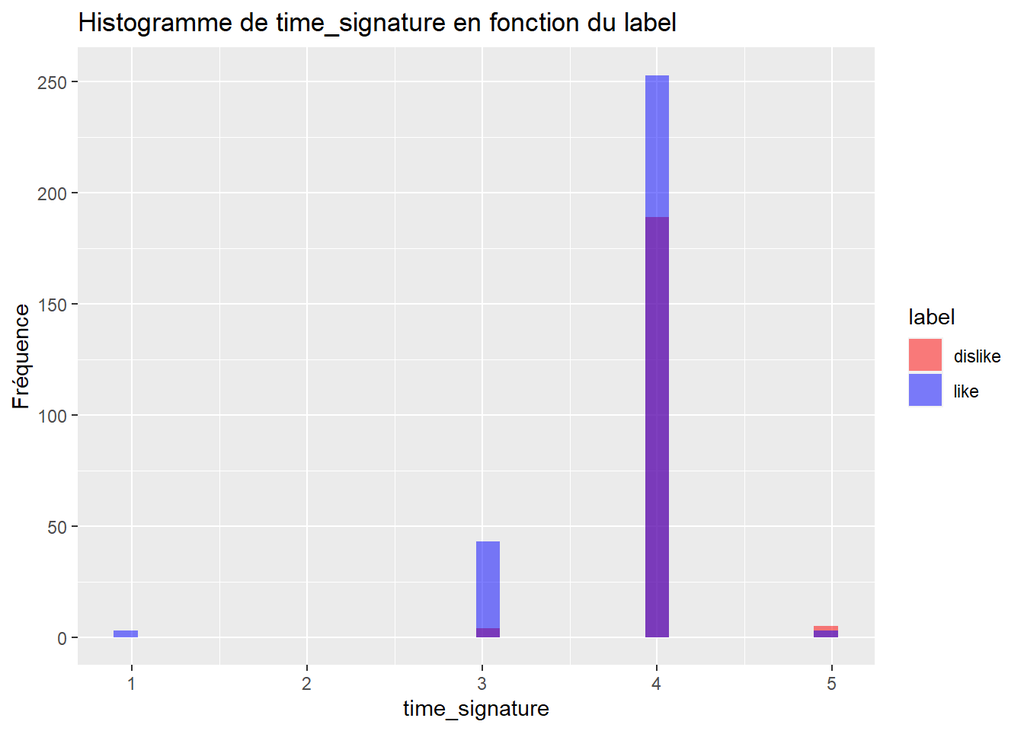

```r
ggplot(data, aes(x = time_signature, fill = label)) +
    geom_histogram(alpha = 0.5, position = "identity", bins = 30) +
    labs(title = "Histogramme de time_signature en fonction du label",
         x = "time_signature",
         y = "Fréquence") +
    scale_fill_manual(values = c("red", "blue"))
```

**Description :**

## Modèle

```r
model_string_time_signature_like <- "
model {
  lambda1 ~ dgamma(4*12, 12)
  lambda2 ~ dgamma(4*12, 12)


  for (i in 1:n1) {
    y1[i] ~ dpois(lambda1)
  }

  for (i in 1:n2) {
    y2[i] ~ dpois(lambda2)
  }
}
"


# Définition des données
y1 <- time_signature_like
y2 <- time_signature_dislike
data_list <- list(y1 = y1, y2 = y2, n1 = length(y1), n2 = length(y2))


# Compiling and producing posterior samples from the model.
jags_samples <- run.jags(model = model_string_time_signature_like, data = data_list, monitor = c("lambda1", "lambda2"))
```

```
## Compiling rjags model...
## Calling the simulation using the rjags method...
## Note: the model did not require adaptation
## Burning in the model for 4000 iterations...
## Running the model for 10000 iterations...
## Simulation complete
## Calculating summary statistics...
## Calculating the Gelman-Rubin statistic for 2 variables....
## Finished running the simulation
```

```r
# Plotting and summarizing the posterior distribution
jags_samples
```

```
##
## JAGS model summary statistics from 20000 samples (chains = 2; adapt+burnin = 5000):
##
##         Lower95 Median Upper95   Mean      SD Mode      MCerr MC%ofSD SSeff
## lambda1  3.6277  3.841  4.0556 3.8425 0.11014   -- 0.00077882     0.7 20000
## lambda2  3.7299  4.004  4.2741 4.0057 0.13801   -- 0.00097585     0.7 20000
##
##             AC.10    psrf
## lambda1  0.013137       1
## lambda2 0.0025168 0.99999
##
## Total time taken: 0.9 seconds
```

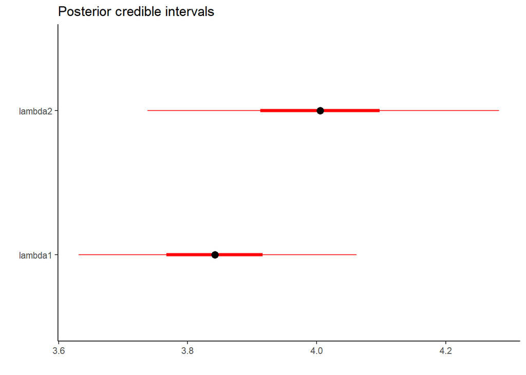

```r
plot_credible_intervals(jags_samples)
```

## Interprétation

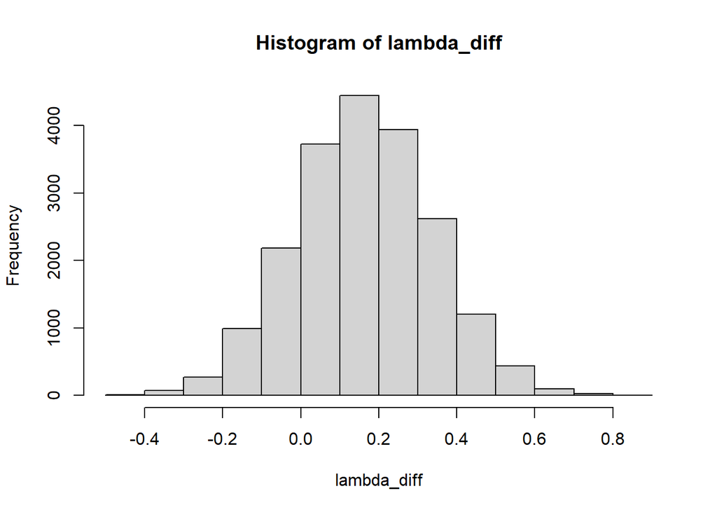

```r
# Conversion des échantillons JAGS en un data frame
jags_samples_df <- as.data.frame(as.mcmc(jags_samples))

# Calcul de la différence entre mu2 et mu1
lambda_diff <- jags_samples_df$lambda2 - jags_samples_df$lambda1

# Tracé de l'histogramme
hist(lambda_diff)
```

```r
mean(lambda_diff > 0)
```

```
## [1] 0.8239
```

## Etude des mcmc

```
## Generating plots...
```

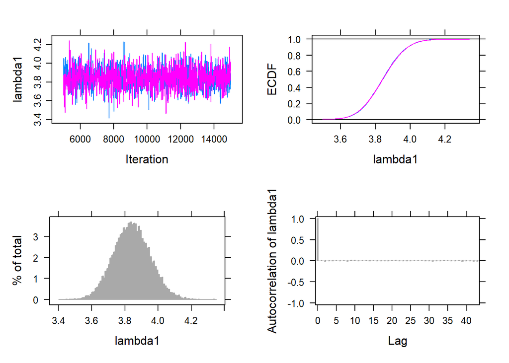

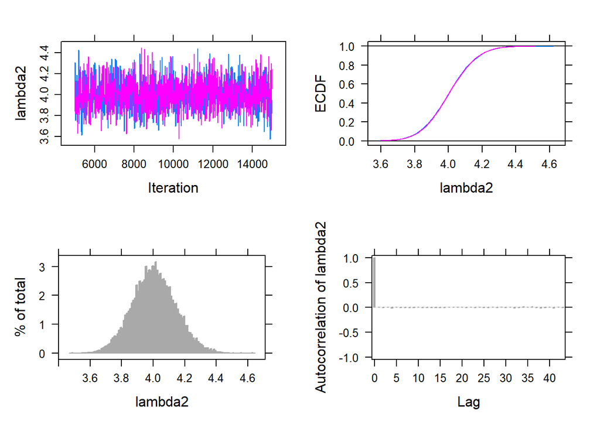

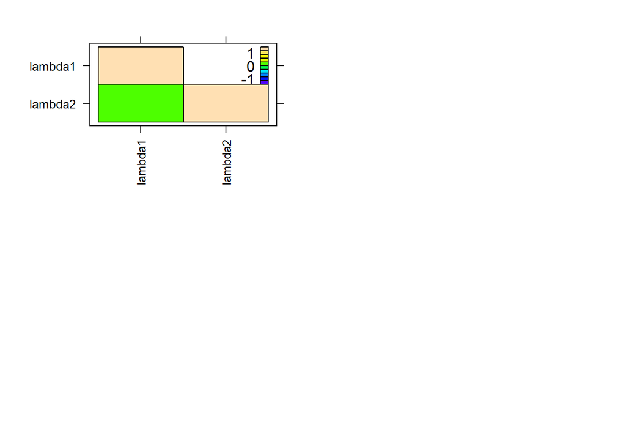

```r
# Installer et charger les packages nécessaires
#install.packages("coda")
library(coda)

# Trace plots
plot(jags_samples)
```

```r
# Gelman-Rubin statistic
gelman.diag(jags_samples)
```

```
## Potential scale reduction factors:
##
##         Point est. Upper C.I.
## lambda1          1          1
## lambda2          1          1
##
## Multivariate psrf
##
## 1
```

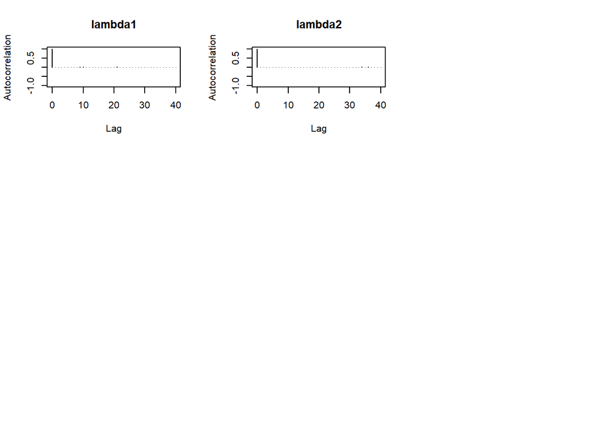

```r
# Autocorrelation plots
autocorr.plot(jags_samples)
```

```r
# Effective sample size
effectiveSize(jags_samples)
```

```
## lambda1 lambda2
##   20000   20000
```

## Fake data check

```r
generate_fake_data <- function(n1, n2) {
  lambda1_fake <- 4  # Utiliser la médiane au lieu de la moyenne
  lambda2_fake <- 5

  # Générer des données factices à partir de la distribution de Poisson
  y1_fake <- rpois(n1, lambda1_fake)
  y2_fake <- rpois(n2, lambda2_fake)

  return(list(y1_fake = y1_fake, y2_fake = y2_fake))
}

# Générer des données factices à partir des échantillons postérieurs
fake_data <- generate_fake_data(length(time_signature_like), length(time_signature_dislike))

# Comparer les données factices avec les données réelles
summary(fake_data$y1_fake)
```

```
##    Min. 1st Qu.  Median    Mean 3rd Qu.    Max.
##   0.000   3.000   4.000   4.003   5.000  11.000
```

```r
summary(fake_data$y2_fake)
```

```
##    Min. 1st Qu.  Median    Mean 3rd Qu.    Max.
##   0.000   3.000   5.000   4.899   6.000  11.000
```

```r
summary(y1)
```

```
##    Min. 1st Qu.  Median    Mean 3rd Qu.    Max.
##   1.000   4.000   4.000   3.838   4.000   5.000
```

```r
summary(y2)
```

```
##    Min. 1st Qu.  Median    Mean 3rd Qu.    Max.
##   3.000   4.000   4.000   4.005   4.000   5.000
```

```r
data_list <- list(y1 = fake_data$y1_fake, y2 = fake_data$y2_fake, n1 = length(fake_data$y1_fake), n2 = length(fake_data$y2_fake))


# Compiling and producing posterior samples from the model.
jags_samples <- run.jags(model = model_string_time_signature_like, data = data_list, monitor = c("lambda1", "lambda2"))
```

```
## Compiling rjags model...
## Calling the simulation using the rjags method...
## Note: the model did not require adaptation
## Burning in the model for 4000 iterations...
## Running the model for 10000 iterations...
## Simulation complete
## Calculating summary statistics...
## Calculating the Gelman-Rubin statistic for 2 variables....
## Finished running the simulation
```

```r
# Plotting and summarizing the posterior distribution
jags_samples
```

```
##
## JAGS model summary statistics from 20000 samples (chains = 2; adapt+burnin = 5000):
##
##         Lower95 Median Upper95   Mean      SD Mode      MCerr MC%ofSD SSeff
## lambda1  3.7817      4  4.2189 4.0017 0.11204   -- 0.00079221     0.7 20000
## lambda2  4.5642 4.8476  5.1531 4.8489 0.15196   --  0.0010745     0.7 20000
##
##             AC.10   psrf
## lambda1  -0.01128      1
## lambda2 0.0039808 1.0002
##
## Total time taken: 0.9 seconds
```

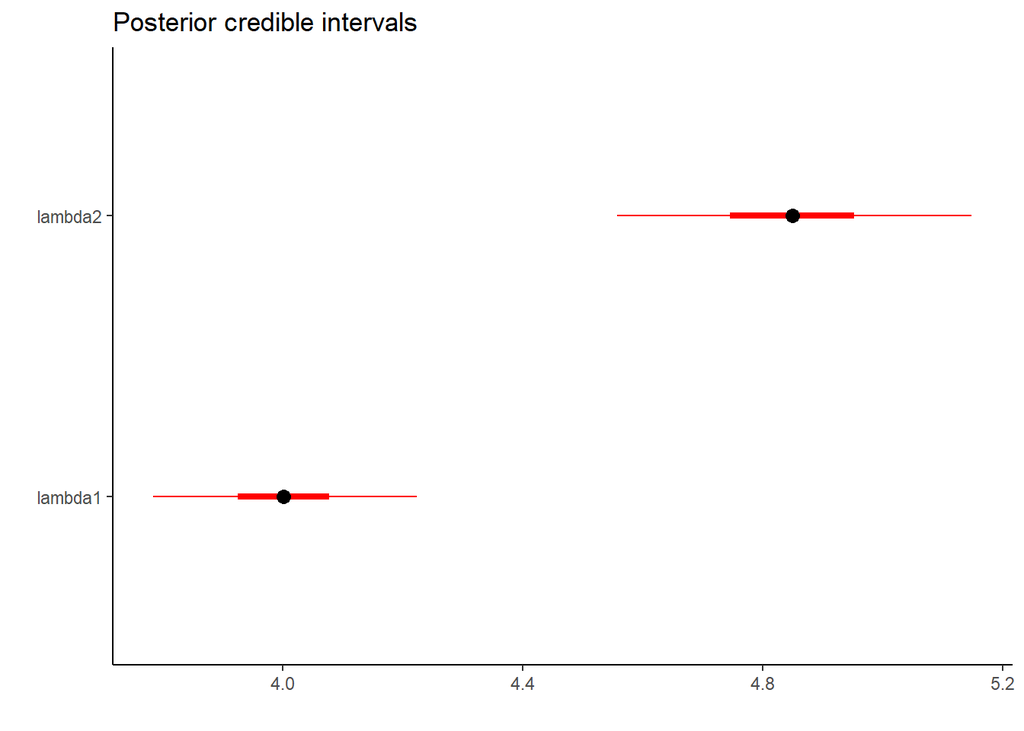

```r
plot_credible_intervals(jags_samples)
```

```r
summary(jags_samples)
```

```
##          Lower95   Median  Upper95     Mean        SD Mode        MCerr MC%ofSD
## lambda1 3.781699 4.000042 4.218941 4.001725 0.1120354   NA 0.0007922097     0.7
## lambda2 4.564216 4.847615 5.153134 4.848930 0.1519614   NA 0.0010745294     0.7
##         SSeff        AC.10     psrf
## lambda1 20000 -0.011280478 1.000021
## lambda2 20000  0.003980797 1.000180
```

# Regression stan_glm

```r
colnames(data)
```

```
##  [1] "danceability"     "energy"           "key"              "loudness"
##  [5] "mode"             "speechiness"      "acousticness"     "instrumentalness"
##  [9] "liveness"         "valence"          "tempo"            "duration"
## [13] "time_signature"   "label"
```

```r
set.seed(123)

# Créer une variable binaire (0 ou 1)
label <- spotify_preferences$label
label <- ifelse(spotify_preferences$label == "like", 1, 0)

# Spécifier le modèle de régression logistique
model <- stan_glm(label ~ danceability + energy +key+  loudness + speechiness + acousticness + instrumentalness + liveness + valence + tempo + duration + time_signature, family = binomial(), data = data)
# Résumé du modèle
summary(model)
```

```
##
## Model Info:
##  function:     stan_glm
##  family:       binomial [logit]
##  formula:      label ~ danceability + energy + key + loudness + speechiness +
##     acousticness + instrumentalness + liveness + valence + tempo +
##     duration + time_signature
##  algorithm:    sampling
##  sample:       4000 (posterior sample size)
##  priors:       see help('prior_summary')
##  observations: 500
##  predictors:   13
##
## Estimates:
##                    mean   sd    10%   50%   90%
## (Intercept)        4.6    2.8   1.1   4.6   8.2
## danceability      -3.2    1.0  -4.4  -3.2  -2.0
## energy            -1.0    1.2  -2.5  -1.0   0.4
## key                0.0    0.0  -0.1   0.0   0.0
## loudness          -0.1    0.1  -0.2  -0.1  -0.1
## speechiness      -12.9    2.1 -15.7 -12.7 -10.2
## acousticness       2.4    0.7   1.5   2.4   3.2
## instrumentalness  -1.2    0.6  -1.9  -1.2  -0.4
## liveness          -0.7    0.8  -1.7  -0.7   0.4
## valence           -0.5    0.7  -1.3  -0.5   0.4
## tempo              0.0    0.0   0.0   0.0   0.0
## duration           0.0    0.0   0.0   0.0   0.0
## time_signature    -1.2    0.6  -2.0  -1.2  -0.5
##
## Fit Diagnostics:
##            mean   sd   10%   50%   90%
## mean_PPD 0.6    0.0  0.6   0.6   0.6
##
## The mean_ppd is the sample average posterior predictive distribution of the outcome variable (for details see help('summary.stanreg')).
##
## MCMC diagnostics
##                  mcse Rhat n_eff
## (Intercept)      0.0  1.0  5568
## danceability     0.0  1.0  4207
## energy           0.0  1.0  3042
## key              0.0  1.0  5829
## loudness         0.0  1.0  3316
## speechiness      0.0  1.0  4747
## acousticness     0.0  1.0  4692
## instrumentalness 0.0  1.0  5160
## liveness         0.0  1.0  4595
## valence          0.0  1.0  4138
## tempo            0.0  1.0  6173
## duration         0.0  1.0  5301
## time_signature   0.0  1.0  6342
## mean_PPD         0.0  1.0  4636
## log-posterior    0.1  1.0  1668
##
## For each parameter, mcse is Monte Carlo standard error, n_eff is a crude measure of effective sample size, and Rhat is the potential scale reduction factor on split chains (at convergence Rhat=1).
```

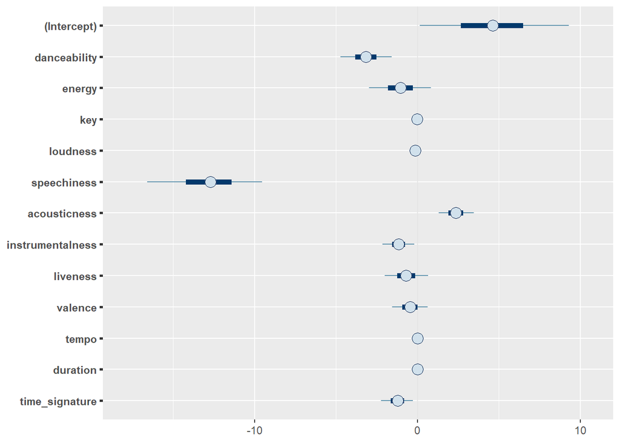

```r
# Afficher les diagnostics
plot(model)
```

# Prédiction

```r
# Charger la librairie nécessaire
#library(caret)

# Faire des prédictions sur les données d'entraînement
predictions <- predict(model, type = "response")

# Seuiller les prédictions à 0 ou 1
threshold <- 0.5
predictions_binary <- ifelse(predictions > threshold, 1, 0)

# Convertir en un vecteur de 0 et 1
datalabel_binary <- ifelse(data$label == "like", 1, 0)

# Calculer l'exactitude
accuracy <- mean(predictions_binary == datalabel_binary)
accuracy
```

```
## [1] 0.816
```

Stevie Wonder At The Close Of A Century I Just Called To Say I Love You

```r
X_new=data.frame(danceability=0.748,energy=0.551,key=1,loudness=-9.054,mode=1,speechiness=0.0239, acousticness=0.243, instrumentalness=1.57e-06, liveness=0.0943, valence= 0.65, tempo=113.535, duration =262240 ,time_signature=4)
```

Ed Sheeran ÷ (Deluxe) Perfect

```r
X_new=data.frame(danceability=0.599,energy=0.448,key=8,loudness=-6.312,mode=1,speechiness=0.0232, acousticness=0.163, instrumentalness=0.0, liveness=0.106, valence= 0.168, tempo=95.05, duration =263400 ,time_signature=3)
# Faire des prédictions sur de nouvelles données
predictions <- predict(model, newdata = X_new, type = "response")

threshold <- 0.5
predictions_ <- ifelse(predictions > threshold, "like", "dislike")
predictions_
```

```
##      1
## "like"
```